# Проект: Исследование стартапов

## Цель и задачи

**Цель:** Провести исследовательский анализ данных для инвестиционного фонда с целью выхода на инвестиционный рынок и дальнейшей покупкой, развитием и последующуей перепродажей перспективных стартапов.

**Задачи:**

1. Загрузить данные и познакомиться с их содержимым.
2. Провести предобработку данных.
3. Провести исследовательский анализ данных и ответить на ряд вопросов от заказчиков.
4. Сформулировать выводы по проведённому анализу, предложить рекомендации.

## Данные

Для анализа используем данные о компаниях и сотрудниках. Данные состоят из пяти основных и двух дополнительных датасетов:

Основные датасеты:

- `acquisition.csv` - Содержит информацию о покупках одними компаниями других компаний;
- `company_and_rounds.csv` - Содержит информацию о компаниях и раундах финансирования;
- `education.csv` - Содержит информацию об образовании сотрудника
- `people.csv` - Содержит информацию о сотрудниках;
- `degrees.csv` - Содержит информацию о типе образования сотрудника

Дополнительные датасеты:

- `fund.csv` - Содержит информацию о фондах
- `investment.csv` - Содержит информацию о раундах инвестирования

### Описание датасета `acquisition`

- `id` — идентификатор покупки.
- `acquiring_company_id` — идентификатор покупающей компании.
- `acquired_company_id` — идентификатор покупаемой компании.
- `term_code` — варианты расчёта.
- `price_amount` — сумма сделки.
- `acquired_at` — дата сделки.

### Описание датасета `company_and_rounds.csv`

- `company ID` — идентификатор компании.
- `name` — название компании.
- `category code` — категория области деятельности компании.
- `status` — статус компании.
- `founded at` — дата инвестирования.
- `closed at` — дата закрытия компании.
- `domain` — официальный сайт компании.
- `network username` — ник компании в сети.
- `country code` — код страны компании.
- `investment rounds` — число инвестиционных раундов.
- `funding rounds` — число раундов финансирования.
- `funding total` — сумма финансирования.
- `milestones` — вехи финансирования.
- `funding round id` — идентификатор этапа финансирования.
- `company id` — идентификатор компании.
- `funded at` — дата финансирования.
- `funding round type` — тип финансирования.
- `raised amount` — сумма финансирования.
- `pre money valuation` — предварительная денежная оценка.
- `participants` — число участников.
- `is first round` — является ли раунд первым.
- `is last round` — является раунд последним.

### Описание датасета `education`

- `id` — идентификатор записи об образовании.
- `person_id` — идентификатор работника.
- `instituition` — название учебного заведения.
- `graduated_at` — дата получения образования.

### Описание датасета `people`

- `id` — идентификатор сотрудника.
- `first_name` — имя сотрудника.
- `last_name` — фамилия сотрудника.
- `company_id` — идентификатор компании.
- `network_username` — ник в социальных сетях.

### Описание датасета `degrees`

- `id` — идентификатор записи.
- `object_id` — идентификатор сотрудника.
- `degree_type` — тип образования.
- `subject` — специальность.

### Описание датасета `fund`

- `id` — идентификатор фонда.
- `name` — название фонда.
- `category_code` — категория области деятельности компании.
- `founded_at` — дата создания фонда.
- `domain` — сайт фонда.
- `network_username` — ник фонда в сети.
- `country_code` — код страны фонда.
- `investment_rounds` — число инвестиционных раундов.
- `invested_companies` — число профинансированных компаний.
- `milestones` — вехи финансирования.

### Описание датасета `investment`

- `id` — идентификатор этапа инвестирования.
- `funding_round_id` — идентификатор раунда инвестирования.
- `company_id` — индентификатор компании.
- `funding_round_type` — тип финансирования.
- `fund_id` — идентификатор фонда.

## Структура проекта

1. Знакомство с данными: загрузка и первичная предобработка
2. Предобработка данных, предварительное исследование
3. Исследовательский анализ объединённых таблиц
4. Итоговый вывод и рекомендации

## Шаг 1. Знакомство с данными: загрузка и первичная предобработка

Названия файлов:

- acquisition.csv
- company_and_rounds.csv
- people.csv
- education.csv
- degrees.csv

Опциональные датасеты:

- fund.csv
- investment.csv

### 1.1. Вывод общей информации, исправление названия столбцов

Загрузим библиотеки:

```python
# Дополнительно загружаем phik для импорта библиотеки phi_k

! pip install phik -q
```

```python
# Дополнительно загружаем matplotlib-venn для импорта библиотеки matplotlib_venn

! pip install matplotlib-venn -q
```

```python
# Импортируем библиотеку pandas
import pandas as pd
import numpy as np

# Загружаем библиотеки для визуализации данных
import matplotlib.pyplot as plt
import seaborn as sns
from matplotlib_venn import venn2

# Загружаем библиотеку для расчёта коэффициента корреляции phi_k
from phik import phik_matrix
```

Загрузим датасеты и сохраним данные датасетов в переменные с соответствующими названиями.

```python
# Производим глобальную настройку отображения формата float
# увеличим кол-во видимых колонок до 30

pd.set_option('display.float_format', '{:,.2f}'.format)
pd.set_option('display.max_columns', 30)

# Выгружаем основные датасеты в переменные acquisition_df, company_and_rounds_df, people_df, education_df, degrees_df
# переменная PATH скрыта, т.к. датафреймы являются интеллектуальной собственностью Я.Практикума
PATH = pd.read_csv('secret_key')

acquisition_df = pd.read_csv(PATH + 'acquisition.csv')
company_and_rounds_df = pd.read_csv(PATH + 'company_and_rounds.csv')
people_df = pd.read_csv(PATH + 'people.csv')
education_df = pd.read_csv(PATH + 'education.csv')
degrees_df = pd.read_csv(PATH + 'degrees.csv')

# Выгружаем дополнительные датасеты в переменные fund_df, investment_df
fund_df = pd.read_csv(PATH + 'fund.csv')
investment_df = pd.read_csv(PATH + 'investment.csv')
```

Проверим корректность наименоваия столбцов каждого датафрейма

```python
# Выводим названия столбцов каждого датафрейма

print(f'Названия столбцов acquisition_df: \n {acquisition_df.columns}\n')
print(f'Названия столбцов company_and_rounds_df: \n {company_and_rounds_df.columns}\n')
print(f'Названия столбцов people_df: \n {people_df.columns}\n')
print(f'Названия столбцов education_df: \n {education_df.columns}\n')
print(f'Названия столбцов degrees_df: \n {degrees_df.columns}\n')

print(f'Названия столбцов fund_df: \n {fund_df.columns}\n')
print(f'Названия столбцов investment_df: \n {investment_df.columns}')
```

```
Названия столбцов acquisition_df:
 Index(['id', 'acquiring_company_id', 'acquired_company_id', 'term_code',
       'price_amount', 'acquired_at'],
      dtype='object')

Названия столбцов company_and_rounds_df:
 Index(['company  ID', 'name', 'category  code', 'status', 'founded  at',
       'closed  at', 'domain', 'network  username', 'country  code',
       'investment  rounds', 'funding  rounds', 'funding  total', 'milestones',
       'funding  round  id', 'company  id', 'funded  at',
       'funding  round  type', 'raised  amount', 'pre  money  valuation',
       'participants', 'is  first  round', 'is  last  round'],
      dtype='object')

Названия столбцов people_df:
 Index(['id', 'first_name', 'last_name', 'company_id', 'network_username'], dtype='object')

Названия столбцов education_df:
 Index(['id', 'person_id', 'instituition', 'graduated_at'], dtype='object')

Названия столбцов degrees_df:
 Index(['id', 'object_id', 'degree_type', 'subject'], dtype='object')

Названия столбцов fund_df:
 Index(['id', 'name', 'founded_at', 'domain', 'network_username',
       'country_code', 'investment_rounds', 'invested_companies',
       'milestones'],
      dtype='object')

Названия столбцов investment_df:
 Index(['id', 'funding_round_id', 'company_id', 'fund_id'], dtype='object')
```

Названия столбцов выглядят корректно, кроме одного - `company_and_rounds_df`. Приведем его к стилю `snake_case`.

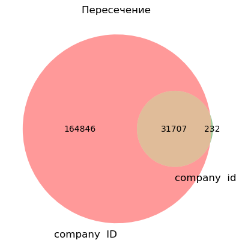

```python
# Построим диаграмму Венна для проверки совпадения столбцов

first_id = set(company_and_rounds_df['company  ID'].dropna().unique())
second_id = set(company_and_rounds_df['company  id'].dropna().unique())
# Строим диаграмму Венна
venn2([first_id, second_id], set_labels=('company  ID', 'company  id'))

# Отображаем график
plt.title("Пересечение ")
plt.show()
```

id в столбцах почти совпадают, поэтому возможно дополнение столбца company ID их company id с последующим удалением последнего

```python
# Для приведения столбцов к стилю snake_case используем метод str.lower() и str.replace()

company_and_rounds_df = company_and_rounds_df.rename(columns={'company  id': 'id_company'}) # чтобы избежать путаницы во время предобработки
company_and_rounds_df.columns = company_and_rounds_df.columns.str.lower()
company_and_rounds_df.columns = company_and_rounds_df.columns.str.replace('  ', '_')
company_and_rounds_df.columns
```

```
Index(['company_id', 'name', 'category_code', 'status', 'founded_at',
       'closed_at', 'domain', 'network_username', 'country_code',
       'investment_rounds', 'funding_rounds', 'funding_total', 'milestones',
       'funding_round_id', 'id_company', 'funded_at', 'funding_round_type',
       'raised_amount', 'pre_money_valuation', 'participants',
       'is_first_round', 'is_last_round'],
      dtype='object')
```

Отобразим информацию о каждом датафрейме. Проверим наличие пропусков, соответствие типов данных - для принятия решения о предобработке данных.

```python
acquisition_df.info()
acquisition_df.head()
```

```
<class 'pandas.core.frame.DataFrame'>
RangeIndex: 9407 entries, 0 to 9406
Data columns (total 6 columns):
 #   Column                Non-Null Count  Dtype
---  ------                --------------  -----
 0   id                    9407 non-null   int64
 1   acquiring_company_id  9407 non-null   int64
 2   acquired_company_id   9407 non-null   int64
 3   term_code             1831 non-null   object
 4   price_amount          9407 non-null   int64
 5   acquired_at           9378 non-null   object
dtypes: int64(4), object(2)
memory usage: 441.1+ KB
```

|  | id | acquiring_company_id | acquired_company_id | term_code | price_amount | acquired_at |
| --- | --- | --- | --- | --- | --- | --- |
| 0 | 1 | 11 | 10 | NaN | 20000000 | 2007-05-30 |
| 1 | 7 | 59 | 72 | cash | 60000000 | 2007-07-01 |
| 2 | 8 | 24 | 132 | cash | 280000000 | 2007-05-01 |
| 3 | 9 | 59 | 155 | cash | 100000000 | 2007-06-01 |
| 4 | 10 | 212 | 215 | cash | 25000000 | 2007-07-01 |

- Обратить внимание на пропуски в `term_code`, `acquired_at`
- При обработке пропусков заменить тип данных в `acquired_at` на `datetime`

```python
company_and_rounds_df.info()
company_and_rounds_df.head(10)
```

```
<class 'pandas.core.frame.DataFrame'>
RangeIndex: 217774 entries, 0 to 217773
Data columns (total 22 columns):
 #   Column               Non-Null Count   Dtype
---  ------               --------------   -----
 0   company_id           217472 non-null  float64
 1   name                 217471 non-null  object
 2   category_code        143886 non-null  object
 3   status               217472 non-null  object
 4   founded_at           109956 non-null  object
 5   closed_at            3449 non-null    object
 6   domain               147159 non-null  object
 7   network_username     95534 non-null   object
 8   country_code         108607 non-null  object
 9   investment_rounds    217472 non-null  float64
 10  funding_rounds       217472 non-null  float64
 11  funding_total        217472 non-null  float64
 12  milestones           217472 non-null  float64
 13  funding_round_id     52928 non-null   float64
 14  id_company           52928 non-null   float64
 15  funded_at            52680 non-null   object
 16  funding_round_type   52928 non-null   object
 17  raised_amount        52928 non-null   float64
 18  pre_money_valuation  52928 non-null   float64
 19  participants         52928 non-null   float64
 20  is_first_round       52928 non-null   float64
 21  is_last_round        52928 non-null   float64
dtypes: float64(12), object(10)
memory usage: 36.6+ MB
```

|  | company_id | name | category_code | status | founded_at | closed_at | domain | network_username | country_code | investment_rounds | funding_rounds | funding_total | milestones | funding_round_id | id_company | funded_at | funding_round_type | raised_amount | pre_money_valuation | participants | is_first_round | is_last_round |
| --- | --- | --- | --- | --- | --- | --- | --- | --- | --- | --- | --- | --- | --- | --- | --- | --- | --- | --- | --- | --- | --- | --- |
| 0 | 1.00 | Wetpaint | web | operating | 2005-10-17 | NaN | wetpaint-inc.com | BachelrWetpaint | USA | 0.00 | 3.00 | 39,750,000.00 | 5.00 | 888.00 | 1.00 | 2005-10-01 | series-a | 5,250,000.00 | 0.00 | 2.00 | 0.00 | 1.00 |
| 1 | 1.00 | Wetpaint | web | operating | 2005-10-17 | NaN | wetpaint-inc.com | BachelrWetpaint | USA | 0.00 | 3.00 | 39,750,000.00 | 5.00 | 889.00 | 1.00 | 2007-01-01 | series-b | 9,500,000.00 | 0.00 | 3.00 | 0.00 | 0.00 |
| 2 | 1.00 | Wetpaint | web | operating | 2005-10-17 | NaN | wetpaint-inc.com | BachelrWetpaint | USA | 0.00 | 3.00 | 39,750,000.00 | 5.00 | 2,312.00 | 1.00 | 2008-05-19 | series-c+ | 25,000,000.00 | 0.00 | 4.00 | 1.00 | 0.00 |
| 3 | 10.00 | Flektor | games_video | acquired | NaN | NaN | flektor.com | NaN | USA | 0.00 | 0.00 | 0.00 | 0.00 | NaN | NaN | NaN | NaN | NaN | NaN | NaN | NaN | NaN |
| 4 | 100.00 | There | games_video | acquired | NaN | NaN | there.com | NaN | USA | 0.00 | 0.00 | 0.00 | 4.00 | NaN | NaN | NaN | NaN | NaN | NaN | NaN | NaN | NaN |
| 5 | 10,000.00 | MYWEBBO | network_hosting | operating | 2008-07-26 | NaN | mywebbo.com | NaN | NaN | 0.00 | 0.00 | 0.00 | 0.00 | NaN | NaN | NaN | NaN | NaN | NaN | NaN | NaN | NaN |
| 6 | 10,001.00 | THE Movie Streamer | games_video | operating | 2008-07-26 | NaN | themoviestreamer.com | NaN | NaN | 0.00 | 0.00 | 0.00 | 0.00 | NaN | NaN | NaN | NaN | NaN | NaN | NaN | NaN | NaN |
| 7 | 10,002.00 | Synergie Media | advertising | operating | 2007-06-27 | NaN | synergie-media.com | NaN | MAR | 0.00 | 0.00 | 0.00 | 0.00 | NaN | NaN | NaN | NaN | NaN | NaN | NaN | NaN | NaN |
| 8 | 10,003.00 | Green Basti Ecosystems | cleantech | operating | 2008-08-20 | NaN | NaN | NaN | IND | 0.00 | 0.00 | 0.00 | 0.00 | NaN | NaN | NaN | NaN | NaN | NaN | NaN | NaN | NaN |
| 9 | 100,042.00 | HostNine | NaN | operating | NaN | NaN | hostnine.com | Hostnine | NaN | 0.00 | 0.00 | 0.00 | 1.00 | NaN | NaN | NaN | NaN | NaN | NaN | NaN | NaN | NaN |

```python
# Ищем строки, имитирующие пропуски в датафрейме

search_nan = company_and_rounds_df.isin(['nan', 'Nan', 'naN', 'nAn', 'NAn', 'nAN', 'NaN', 'na', 'Na', 'nA'])
rows_nan = company_and_rounds_df[search_nan.any(axis=1)]
rows_nan
```

|  | company_id | name | category_code | status | founded_at | closed_at | domain | network_username | country_code | investment_rounds | funding_rounds | funding_total | milestones | funding_round_id | id_company | funded_at | funding_round_type | raised_amount | pre_money_valuation | participants | is_first_round | is_last_round |
| --- | --- | --- | --- | --- | --- | --- | --- | --- | --- | --- | --- | --- | --- | --- | --- | --- | --- | --- | --- | --- | --- | --- |
| 679 | 103,486.00 | Neighborhood Basketball Program | other | operating | 2003-01-06 | NaN | sdnbp.com | na | NaN | 0.00 | 0.00 | 0.00 | 0.00 | NaN | NaN | NaN | NaN | NaN | NaN | NaN | NaN | NaN |
| 93410 | 230,896.00 | na | software | operating | 2013-06-15 | NaN | NaN | NaN | USA | 0.00 | 0.00 | 0.00 | 1.00 | NaN | NaN | NaN | NaN | NaN | NaN | NaN | NaN | NaN |
| 170494 | 44,153.00 | Monitor Online Reputation | other | operating | NaN | NaN | monitoronlinereputation.com | na | NaN | 0.00 | 0.00 | 0.00 | 0.00 | NaN | NaN | NaN | NaN | NaN | NaN | NaN | NaN | NaN |

```python
people_df.info()
people_df.head(10)
```

```
<class 'pandas.core.frame.DataFrame'>
RangeIndex: 226709 entries, 0 to 226708
Data columns (total 5 columns):
 #   Column            Non-Null Count   Dtype
---  ------            --------------   -----
 0   id                226709 non-null  int64
 1   first_name        226700 non-null  object
 2   last_name         226705 non-null  object
 3   company_id        34615 non-null   float64
 4   network_username  38867 non-null   object
dtypes: float64(1), int64(1), object(3)
memory usage: 8.6+ MB
```

|  | id | first_name | last_name | company_id | network_username |
| --- | --- | --- | --- | --- | --- |
| 0 | 10 | Mark | Zuckerberg | 5.00 | NaN |
| 1 | 100 | Peter | Lester | 27.00 | NaN |
| 2 | 1000 | Dr. Steven | E. Saunders | 292.00 | NaN |
| 3 | 10000 | Neil | Capel | 2,526.00 | NaN |
| 4 | 100000 | Sue | Pilsch | NaN | NaN |
| 5 | 100002 | Keith | Kurzendoerfer | NaN | NaN |
| 6 | 100006 | Courtney | Homer | 81,558.00 | jobsbostontech |
| 7 | 100009 | Eddy | Badrina | NaN | NaN |
| 8 | 100010 | Michael | Dadashyan | NaN | fbroulette |
| 9 | 100011 | Jeff | Grell | NaN | NaN |

- Пропуски в столбцах `company_id` и `network_username`
- При обработке пропусков в столбце `company_id` заменить тип данных на `int`

```python
education_df.info()
education_df.head()
```

```
<class 'pandas.core.frame.DataFrame'>
RangeIndex: 109610 entries, 0 to 109609
Data columns (total 4 columns):
 #   Column        Non-Null Count   Dtype
---  ------        --------------   -----
 0   id            109610 non-null  int64
 1   person_id     109610 non-null  int64
 2   instituition  109555 non-null  object
 3   graduated_at  58054 non-null   object
dtypes: int64(2), object(2)
memory usage: 3.3+ MB
```

|  | id | person_id | instituition | graduated_at |
| --- | --- | --- | --- | --- |
| 0 | 1 | 6117 | NaN | NaN |
| 1 | 2 | 6136 | Washington University, St. Louis | 1990-01-01 |
| 2 | 3 | 6136 | Boston University | 1992-01-01 |
| 3 | 4 | 6005 | University of Greenwich | 2006-01-01 |
| 4 | 5 | 5832 | Rice University | NaN |

```python
# Исправим опечатку в колонке instituition

education_df = education_df.rename(columns={'instituition': 'institution'})
```

- Пропуски в столбце `graduated_at` и `institution`
- При обработке пропусков в столбце `graduated_at` заменить тип данных на `datetime`

```python
degrees_df.info()
degrees_df.head(15)
```

```
<class 'pandas.core.frame.DataFrame'>
RangeIndex: 109610 entries, 0 to 109609
Data columns (total 4 columns):
 #   Column       Non-Null Count   Dtype
---  ------       --------------   -----
 0   id           109610 non-null  int64
 1   object_id    109610 non-null  object
 2   degree_type  98389 non-null   object
 3   subject      81298 non-null   object
dtypes: int64(1), object(3)
memory usage: 3.3+ MB
```

|  | id | object_id | degree_type | subject |
| --- | --- | --- | --- | --- |
| 0 | 1 | p:6117 | MBA | NaN |
| 1 | 2 | p:6136 | BA | English, French |
| 2 | 3 | p:6136 | MS | Mass Communication |
| 3 | 4 | p:6005 | MS | Internet Technology |
| 4 | 5 | p:5832 | BCS | Computer Science, Psychology |
| 5 | 6 | p:1017 | BS | Computer Science |
| 6 | 7 | p:6176 | BS | Computer Science |
| 7 | 8 | p:5412 | MS | Politics |
| 8 | 9 | p:1243 | BA | International Business & Marketing |
| 9 | 10 | p:6265 | BS | Economics |
| 10 | 11 | p:6328 | Foundation | Computing and Internet Technology |
| 11 | 12 | p:6329 | MA | Physics & Philosophy |
| 12 | 13 | p:2351 | LLB | Law |
| 13 | 14 | p:2351 | BA | Economics |
| 14 | 15 | p:5471 | MS | Media & Knowledge Engineering |

```python
fund_df.info()
fund_df.head(15)
```

```
<class 'pandas.core.frame.DataFrame'>
RangeIndex: 11652 entries, 0 to 11651
Data columns (total 9 columns):
 #   Column              Non-Null Count  Dtype
---  ------              --------------  -----
 0   id                  11652 non-null  int64
 1   name                11649 non-null  object
 2   founded_at          4605 non-null   object
 3   domain              7362 non-null   object
 4   network_username    2149 non-null   object
 5   country_code        7053 non-null   object
 6   investment_rounds   11652 non-null  int64
 7   invested_companies  11652 non-null  int64
 8   milestones          11652 non-null  int64
dtypes: int64(4), object(5)
memory usage: 819.4+ KB
```

|  | id | name | founded_at | domain | network_username | country_code | investment_rounds | invested_companies | milestones |
| --- | --- | --- | --- | --- | --- | --- | --- | --- | --- |
| 0 | 13131 | NaN | NaN | NaN | NaN | NaN | 0 | 0 | 0 |
| 1 | 1 | Greylock Partners | 1965-01-01 | greylock.com | greylockvc | USA | 307 | 196 | 0 |
| 2 | 10 | Mission Ventures | 1996-01-01 | missionventures.com | NaN | USA | 58 | 33 | 0 |
| 3 | 100 | Kapor Enterprises, Inc. | NaN | kei.com | NaN | USA | 2 | 1 | 0 |
| 4 | 1000 | Speed Ventures | NaN | NaN | NaN | NaN | 0 | 0 | 1 |
| 5 | 10000 | 3x5 Special Opportunity Partners | NaN | NaN | NaN | NaN | 4 | 4 | 0 |
| 6 | 10001 | Salem Partners | 1997-01-01 | salempartners.com | NaN | USA | 1 | 1 | 0 |
| 7 | 10002 | 3T Capital | NaN | 3tcapital.com | NaN | FRA | 3 | 3 | 0 |
| 8 | 10003 | Merieux Developpement | 2009-01-01 | merieux-developpement.com | NaN | FRA | 2 | 2 | 0 |
| 9 | 10004 | Aquasourca | NaN | aquasourca.com | NaN | FRA | 1 | 1 | 0 |
| 10 | 10005 | Texas Entrepreneur Networks | 2009-01-01 | texasenetworks.com | NaN | USA | 1 | 1 | 0 |
| 11 | 10007 | Precedent Investments | NaN | NaN | NaN | NaN | 1 | 1 | 0 |
| 12 | 10008 | Navitrio | NaN | navitrio.com | NaN | ISR | 1 | 1 | 0 |
| 13 | 1001 | Burch Investment Group | NaN | NaN | NaN | USA | 1 | 1 | 0 |
| 14 | 10011 | DRAW | NaN | NaN | NaN | NaN | 0 | 0 | 0 |

```python
# Ищем строки, имитирующие пропуски в датафрейме

search_nan_fund = fund_df.isin(['nan', 'Nan', 'naN', 'nAn', 'NAn', 'nAN', 'NaN', 'na', 'Na', 'nA'])
rows_nan_fund = fund_df[search_nan_fund.any(axis=1)]
rows_nan_fund
```

|  | id | name | founded_at | domain | network_username | country_code | investment_rounds | invested_companies | milestones |
| --- | --- | --- | --- | --- | --- | --- | --- | --- | --- |

- Пропуски в `degree_type` и `subject`

Вывод по содержанию данных:

Таблицы содержат пропуски, которые необходимо изучить дополнительно.

Кроме того, типы данных некоторых столбцов не соответствуют самим данным, в частности колонки с датой. Необходимо заменить их

### 1.2. Смена типов и анализ пропусков

> - Обработаем типы данных в столбцах, которые хранят значения даты и времени.
> - Оценим полноту данных и сделаем предварительный вывод, достаточно ли данных для решения задач проекта.

Преобразуем столбцы `acquired_at`, `founded_at`, `funded_at`, `graduated_at` в тип `datetime64[ns]`.

```python
# Преобразовываем дату из формата object в формат datetime64[ns]

acquisition_df['acquired_at'] = pd.to_datetime(acquisition_df['acquired_at'], errors='coerce')

education_df['graduated_at'] = pd.to_datetime(education_df['graduated_at'], errors='coerce')

company_and_rounds_df['founded_at'] = pd.to_datetime(company_and_rounds_df['founded_at'], errors='coerce')

company_and_rounds_df['funded_at'] = pd.to_datetime(company_and_rounds_df['funded_at'], errors='coerce')

# Преобразование даты для извлечения года
company_and_rounds_df['funded_at_year'] = company_and_rounds_df['funded_at'].dt.year.astype('Int16')
```

```python
# Проверим преобразование типов данных
type_acq = acquisition_df['acquired_at'].dtypes
type_qra = education_df['graduated_at'].dtypes

print(f'acquired_at   {type_acq}')
print(company_and_rounds_df[['founded_at', 'funded_at']].dtypes)
print(f'graduated_at  {type_qra}')
```

```
acquired_at   datetime64[ns]
founded_at    datetime64[ns]
funded_at     datetime64[ns]
dtype: object
graduated_at  datetime64[ns]
```

Проанализируем пропуски в данных для дальнейшего решения задач.

Для этого используем методы `isna().sum()` для отображения в абсолютных значениях и `isna().mean()` для отображения в относительных значениях. Отсортируем с помощью `sort_values(ascending=False)`

```python
# Создаем функцию для анализа пропусков
def missing_values_info(df):
    missing_abs = df.isna().sum().sort_values(ascending=False)  # Абсолютное количество пропусков
    missing_rel = round(df.isna().mean().sort_values(ascending=False) * 100, 2)  # Относительное количество пропусков
    return pd.concat([missing_abs, missing_rel], axis=1, keys=['Кол-во', '% пропусков']) # Соединяем в датафрейм

# Анализируем пропуски для каждого датафрейма
acquisition_missing = missing_values_info(acquisition_df)
company_and_rounds_missing = missing_values_info(company_and_rounds_df)
people_missing = missing_values_info(people_df)
education_missing = missing_values_info(education_df)
degrees_missing = missing_values_info(degrees_df)

# Отобразим кол-во пропусков
for var in [company_and_rounds_missing]:
    print(f' {var} \n')
```

```
                      Кол-во  % пропусков
closed_at            214325        98.42
funded_at_year       165094        75.81
funded_at            165094        75.81
is_first_round       164846        75.70
id_company           164846        75.70
funding_round_id     164846        75.70
pre_money_valuation  164846        75.70
participants         164846        75.70
funding_round_type   164846        75.70
raised_amount        164846        75.70
is_last_round        164846        75.70
network_username     122240        56.13
country_code         109167        50.13
founded_at           107818        49.51
category_code         73888        33.93
domain                70615        32.43
name                    303         0.14
company_id              302         0.14
milestones              302         0.14
funding_rounds          302         0.14
investment_rounds       302         0.14
status                  302         0.14
funding_total           302         0.14
```

```python
# Отобразим кол-во пропусков

for var in [acquisition_missing, people_missing, education_missing, degrees_missing]:
    print(f' {var} \n')
```

```
                       Кол-во  % пропусков
term_code               7576        80.54
acquired_at               29         0.31
id                         0         0.00
acquiring_company_id       0         0.00
acquired_company_id        0         0.00
price_amount               0         0.00

                   Кол-во  % пропусков
company_id        192094        84.73
network_username  187842        82.86
first_name             9         0.00
last_name              4         0.00
id                     0         0.00

               Кол-во  % пропусков
graduated_at   51556        47.04
institution       55         0.05
id                 0         0.00
person_id          0         0.00

              Кол-во  % пропусков
subject       28312        25.83
degree_type   11221        10.24
id                0         0.00
object_id         0         0.00
```

**Вывод по пропускам:**

`acquisition_missing`: большое кол-во пропусков в столбце `term_code` (80,5%). Удалить такой столбец нельзя, т.к. это большая часть данных, заполнение невозможно, потому что приведет к искажению данных. Анализу не подлежит

`people_missing`: Много пропусков в столбцах `company_id` (85%) и `network_username` (83%). Удаление и заполнение невозможно, при этом могут возникнуть проблемы с присоединением данных. Подумать над присоединеничем через другие столбцы

`education_missing`: Много пропусков в столбце `graduated_at` (47%). Удаление и заполнение невозможно, т.к. приведет к искажению данных. В анализе не участвует, можно оставить как есть.

`degrees_missing`: Значительное кол-во пропусков в `subject` (26%) и `degree_type` (10%). Обработка может исказть выводы, при этом столбцы не участвуют в анализе.

#### Вывод по "Шаг 1. Знакомство с данными: загрузка и первичная предобработка":

1. Загрузка данных:
- Были загружены датафреймы, содержащие информацию о компаниях-стартапах и их инвестициях.
2. Приведение к общему стилю:
- Заменили стиль на snake case
3. Несоответствие типов данных:

Некоторые столбцы имеют некорректные типы данных - столбцы с датами представлены с типом object. В рамках предварительно обработки преобразовали в datetime.

4. Обнаруженные пропуски:
- В данных присутствуют пропуски, которые необходимо изучить и при необходимости обработать.

Для дальнейшего анализа потребуется:

- Проанализировать пропуски для каждой таблицы и при необходимости их обработать.

## Шаг 2. Предобработка данных, предварительное исследование

### 2.1. Раунды финансирования по годам

- Составим сводную таблицу по годам, в которой на основании столбца `raised_amount` для каждого года указан:
  - типичный размер средств, выделяемый в рамках одного раунда;
  - общее количество раундов финансирования за этот год.
- Оставим в таблице информацию только для тех лет, для которых есть информация о более чем 50 раундах финансирования.
- На основе получившейся таблицы построим график, который будет отражать динамику типичного размера средств, которые стартапы получали в рамках одного раунда финансирования.

На основе полученных данных ответим на вопросы:

- В каком году типичный размер собранных в рамках одного раунда средств был максимален?
- Какая тенденция по количеству раундов и выделяемых в рамках каждого раунда средств наблюдалась в 2013 году?

```python
# Чтобы определиться с выбором медианы или среднего, посмотрим на наличие выбросов

company_and_rounds_df['raised_amount'].describe()
```

```
count          52,928.00
mean        7,946,092.26
std        42,168,205.89
min                 0.00
25%           246,330.00
50%         1,600,000.00
75%         6,700,000.00
max     3,835,050,000.00
Name: raised_amount, dtype: float64
```

Так как среднее в разы превышает медиану, то это указывает на выбросы в большую сторону. Для более корректного анализа будем использовать медиану

```python
# Создадим сводную таблицу pivot_table (сокращение для переменных pt)
# для нормального отображения колонки со средним значением финансирования
pd.options.display.float_format = '{:.2f}'.format

company_and_rounds_pt = company_and_rounds_df.pivot_table(
    index='funded_at_year',
    values=['raised_amount', 'funding_rounds'],
    aggfunc={'raised_amount': 'median', 'funding_rounds': 'count'}
).reset_index()

# Переименуем столбцы
company_and_rounds_pt.columns = ['funded_at_year', 'cnt_funding_rounds', 'median_raised_amount']

# Отфильтруем по кол-ву ранудов более 50
company_and_rounds_pt = company_and_rounds_pt[company_and_rounds_pt['cnt_funding_rounds'] > 50]

company_and_rounds_pt
```

|  | funded_at_year | cnt_funding_rounds | median_raised_amount |
| --- | --- | --- | --- |
| 15 | 1999 | 76 | 2000000.00 |
| 16 | 2000 | 125 | 4200000.00 |
| 17 | 2001 | 95 | 3000000.00 |
| 18 | 2002 | 115 | 4200000.00 |
| 19 | 2003 | 154 | 3000000.00 |
| 20 | 2004 | 286 | 5000000.00 |
| 21 | 2005 | 1624 | 5500000.00 |
| 22 | 2006 | 2409 | 5000000.00 |
| 23 | 2007 | 3220 | 3973320.00 |
| 24 | 2008 | 3735 | 3110000.00 |
| 25 | 2009 | 4112 | 2000000.00 |
| 26 | 2010 | 6194 | 1602500.00 |
| 27 | 2011 | 9162 | 1200000.00 |
| 28 | 2012 | 9956 | 1000000.00 |
| 29 | 2013 | 11042 | 1200000.00 |

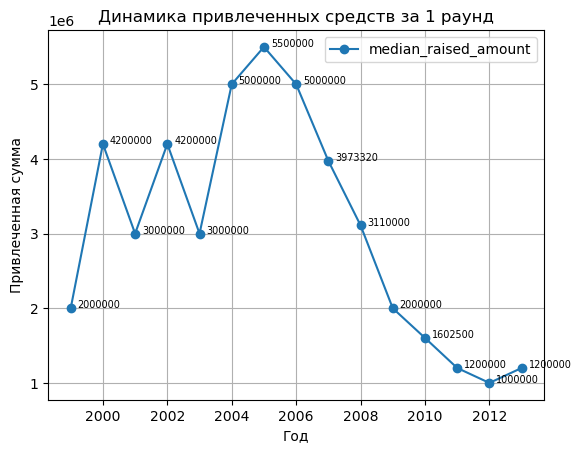

```python
# Построим линейный график по динамике привлечения средств в рамках 1 раунда

line_graph1 = company_and_rounds_pt.plot.line(x='funded_at_year',
                                y='median_raised_amount',
                                legend=True,
                                marker='o',
                                title='Динамика привлеченных средств за 1 раунд',
                                xlabel='Год',
                                ylabel='Привлеченная сумма')
for x, y in zip(company_and_rounds_pt['funded_at_year'], company_and_rounds_pt['median_raised_amount']):
    line_graph1.annotate(f'{y:.0f}', xy=(x, y), textcoords='offset points', xytext=(5, 0), ha='left', fontsize=7)

plt.grid(True)
plt.show()
```

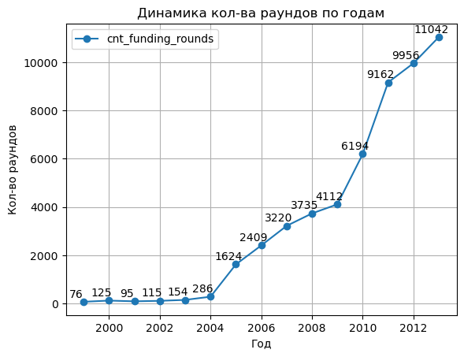

```python
# Построим линейный график по динамике

line_graph2 = company_and_rounds_pt.plot.line(x='funded_at_year',
                                y='cnt_funding_rounds',
                                legend=True,
                                marker='o',
                                title='Динамика кол-ва раундов по годам',
                                xlabel='Год',
                                ylabel='Кол-во раундов')
for x, y in zip(company_and_rounds_pt['funded_at_year'], company_and_rounds_pt['cnt_funding_rounds']):
    line_graph2.annotate(f'{y:.0f}', xy=(x, y), textcoords='offset points', xytext=(-7, 4), ha='center')

plt.grid(True)
plt.show()
```

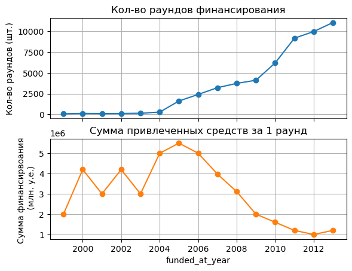

```python
# Строим график с подграфиком для отображения тенденции

pt_subline = company_and_rounds_pt[['funded_at_year', 'cnt_funding_rounds', 'median_raised_amount']]
pt_subline = pt_subline.set_index('funded_at_year')

subline = pt_subline.plot(kind='line',
                   subplots=True,
                   sharex=True,
                   sharey=False,
                   legend=False,
                   marker='o', # Установка маркера для точек
                   title=['Кол-во раундов финансирования', 'Сумма привлеченных средств за 1 раунд'])

# Устанавливаем подпись для оси Y каждого из подграфиков
subline[0].set_ylabel('Кол-во раундов (шт.)')
subline[1].set_ylabel('Сумма финансирвоания \n (млн. у.е.)')

# Включаем сетку для каждого из подграфиков
subline[0].grid(which='both')
subline[1].grid(which='both')

plt.show()
```

#### Вывод:

> - В каком году типичный размер собранных в рамках одного раунда средств был максимален?

В 2005 году был максимальный размер собранных средств в рамках 1 раунда - 5500000 у.е. по медиане

### 2.2. Люди и их образование

Заказчик хочет понять, зависит ли полнота сведений о сотрудниках (например, об их образовании) от размера компаний.

- Оценим, насколько информация об образовании сотрудников полна. Используя датасеты `people.csv` и `education.csv`, разделим все компании на несколько групп по количеству сотрудников и оценим среднюю долю сотрудников без информации об образовании в каждой из групп.
- Оценим, возможно ли для выполнения задания присоединить к этим таблицам ещё и таблицу `degrees.csv`.

> Исходя из знакомства с данными и описанием каждого столбца, можно сделать вывод, что для ответа на вопрос возможно присоединение датафрейма degree_df, так как он содержит информацию об образовании или специальности

```python
# Переименуем столбец id в датафрейме people_df для правильного присоединения и корректного анализа
# Переименуем столбец id в датафрейме degrees_df

people_df = people_df.rename(columns={'id': 'person_id'})
degrees_df = degrees_df.rename(columns={'id': 'degrees_id'})
```

```python
# Предобработаем колонку `object_id`, убрав префикс `p.` и переведя тип в числовой

degrees_df['object_id'] = degrees_df['object_id'].str.slice(3,)

degrees_df['object_id'] = pd.to_numeric(degrees_df['object_id'], errors='raise')
```

Перед присоединением проверим удалим дубликаты в датафреймах, чтобы не произошло дублирование строк.

```python
# Посчитаем кол-во дублей по столбцу, по которому будем присоединять датафреймы

duplicates_people_df = people_df.duplicated(subset=['person_id']).sum()
print(f'Кол-во дублей в people_df: {duplicates_people_df}')

duplicates_education_df = education_df.duplicated(subset=['person_id']).sum()
print(f'Кол-во дублей в education_df: {duplicates_education_df}')

duplicates_degrees_df = degrees_df.duplicated(subset=['object_id']).sum()
print(f'Кол-во дублей в degrees_df: {duplicates_degrees_df}')
```

```
Кол-во дублей в people_df: 1
Кол-во дублей в education_df: 41159
Кол-во дублей в degrees_df: 62610
```

```python
# Удалим дубликаты

people_df = people_df.drop_duplicates(subset=['person_id'])

education_df = education_df.drop_duplicates(subset=['person_id'])

degrees_df = degrees_df.drop_duplicates(subset=['object_id'])
```

```python
# Объединим датафреймы people и education

people_edu_df = people_df.merge(education_df, on='person_id', how='left')

people_edu_df.info()
people_edu_df.head(10)
```

```
<class 'pandas.core.frame.DataFrame'>
RangeIndex: 226708 entries, 0 to 226707
Data columns (total 8 columns):
 #   Column            Non-Null Count   Dtype
---  ------            --------------   -----
 0   person_id         226708 non-null  int64
 1   first_name        226699 non-null  object
 2   last_name         226704 non-null  object
 3   company_id        34614 non-null   float64
 4   network_username  38867 non-null   object
 5   id                68071 non-null   float64
 6   institution       68031 non-null   object
 7   graduated_at      36387 non-null   datetime64[ns]
dtypes: datetime64[ns](1), float64(2), int64(1), object(4)
memory usage: 13.8+ MB
```

|  | person_id | first_name | last_name | company_id | network_username | id | institution | graduated_at |
| --- | --- | --- | --- | --- | --- | --- | --- | --- |
| 0 | 10 | Mark | Zuckerberg | 5.00 | NaN | 2415.00 | Harvard University | NaT |
| 1 | 100 | Peter | Lester | 27.00 | NaN | NaN | NaN | NaT |
| 2 | 1000 | Dr. Steven | E. Saunders | 292.00 | NaN | NaN | NaN | NaT |
| 3 | 10000 | Neil | Capel | 2526.00 | NaN | NaN | NaN | NaT |
| 4 | 100000 | Sue | Pilsch | NaN | NaN | NaN | NaN | NaT |
| 5 | 100002 | Keith | Kurzendoerfer | NaN | NaN | NaN | NaN | NaT |
| 6 | 100006 | Courtney | Homer | 81558.00 | jobsbostontech | 83604.00 | MIT Sloan School of Management | 2004-01-01 |
| 7 | 100009 | Eddy | Badrina | NaN | NaN | NaN | NaN | NaT |
| 8 | 100010 | Michael | Dadashyan | NaN | fbroulette | NaN | NaN | NaT |
| 9 | 100011 | Jeff | Grell | NaN | NaN | NaN | NaN | NaT |

```python
# Объединим датафреймы people и education

people_edu_deg_df = people_edu_df.merge(degrees_df, left_on='person_id', right_on='object_id', how='left')

people_edu_deg_df.info()
people_edu_deg_df.head(10)
```

```
<class 'pandas.core.frame.DataFrame'>
RangeIndex: 226708 entries, 0 to 226707
Data columns (total 12 columns):
 #   Column            Non-Null Count   Dtype
---  ------            --------------   -----
 0   person_id         226708 non-null  int64
 1   first_name        226699 non-null  object
 2   last_name         226704 non-null  object
 3   company_id        34614 non-null   float64
 4   network_username  38867 non-null   object
 5   id                68071 non-null   float64
 6   institution       68031 non-null   object
 7   graduated_at      36387 non-null   datetime64[ns]
 8   degrees_id        40815 non-null   float64
 9   object_id         40815 non-null   float64
 10  degree_type       36881 non-null   object
 11  subject           30409 non-null   object
dtypes: datetime64[ns](1), float64(4), int64(1), object(6)
memory usage: 20.8+ MB
```

|  | person_id | first_name | last_name | company_id | network_username | id | institution | graduated_at | degrees_id | object_id | degree_type | subject |
| --- | --- | --- | --- | --- | --- | --- | --- | --- | --- | --- | --- | --- |
| 0 | 10 | Mark | Zuckerberg | 5.00 | NaN | 2415.00 | Harvard University | NaT | 485.00 | 10.00 | CEMS Master | International Management |
| 1 | 100 | Peter | Lester | 27.00 | NaN | NaN | NaN | NaT | 2445.00 | 100.00 | MS | Computer Science |
| 2 | 1000 | Dr. Steven | E. Saunders | 292.00 | NaN | NaN | NaN | NaT | 2817.00 | 1000.00 | BS | Computer Science |
| 3 | 10000 | Neil | Capel | 2526.00 | NaN | NaN | NaN | NaT | NaN | NaN | NaN | NaN |
| 4 | 100000 | Sue | Pilsch | NaN | NaN | NaN | NaN | NaT | NaN | NaN | NaN | NaN |
| 5 | 100002 | Keith | Kurzendoerfer | NaN | NaN | NaN | NaN | NaT | NaN | NaN | NaN | NaN |
| 6 | 100006 | Courtney | Homer | 81558.00 | jobsbostontech | 83604.00 | MIT Sloan School of Management | 2004-01-01 | NaN | NaN | NaN | NaN |
| 7 | 100009 | Eddy | Badrina | NaN | NaN | NaN | NaN | NaT | NaN | NaN | NaN | NaN |
| 8 | 100010 | Michael | Dadashyan | NaN | fbroulette | NaN | NaN | NaT | NaN | NaN | NaN | NaN |
| 9 | 100011 | Jeff | Grell | NaN | NaN | NaN | NaN | NaT | NaN | NaN | NaN | NaN |

```python
# Считаем сумму дубликатов, используя метод duplicated для обозначения строки дубликатом bool True и sum для подсчета значений True

all_duplicated = people_edu_deg_df.duplicated().sum()

display(f'Кол-во дублей: {all_duplicated}')

# Выводим дубликаты. Используем параметр keep=False, чтобы проверить корректность работы метода duplicated

duplicated_row = people_edu_deg_df[(people_edu_deg_df.duplicated())]

duplicated_row
```

```
'Кол-во дублей: 0'
```

|  | person_id | first_name | last_name | company_id | network_username | id | institution | graduated_at | degrees_id | object_id | degree_type | subject |
| --- | --- | --- | --- | --- | --- | --- | --- | --- | --- | --- | --- | --- |

Перед анализом стоит определиться, что считать за наличие или отсутствие информации об образовании. Так как в техническом задании нет конкретной формулировки, то за данное возьмем, что наличие образования будет указано в следующих столбцах: `id`, `institution`, `degree_type`, `subject` и `graduated_at`. Они сигнализируют, что у сотрудника указана либо информация об образовании, либо тип образования, либо место обучения, либо специальность, либо дата окончания обучения

Объединяющим столбцом должен быть `id`. Для этого проверим наличие информации об образовании, если в столбце `id` пропуск.

```python
people_edu_deg_df[people_edu_deg_df['id'].isna() &
                  people_edu_deg_df[['institution', 'degree_type', 'subject', 'graduated_at']].notna().any(axis=1)].head(10)
```

|  | person_id | first_name | last_name | company_id | network_username | id | institution | graduated_at | degrees_id | object_id | degree_type | subject |
| --- | --- | --- | --- | --- | --- | --- | --- | --- | --- | --- | --- | --- |
| 1 | 100 | Peter | Lester | 27.00 | NaN | NaN | NaN | NaT | 2445.00 | 100.00 | MS | Computer Science |
| 2 | 1000 | Dr. Steven | E. Saunders | 292.00 | NaN | NaN | NaN | NaT | 2817.00 | 1000.00 | BS | Computer Science |
| 62 | 10008 | Olivier | Schaal | 4887.00 | NaN | NaN | NaN | NaT | 53087.00 | 10008.00 | BS | Business Administration |
| 69 | 10009 | ahmed | M.I | NaN | NaN | NaN | NaN | NaT | 16184.00 | 10009.00 | M. Tech | Thermal Engg. |
| 75 | 1001 | Richard | I. Kadet | 292.00 | NaN | NaN | NaN | NaT | 7507.00 | 1001.00 | B.S. with Honors and Distinction | Biochemistry, Economics |
| 76 | 10010 | Ms. | Hadas Melnik | NaN | NaN | NaN | NaN | NaT | 16185.00 | 10010.00 | BA | English/Creative Writing |
| 91 | 10012 | Basab | Pradhan | NaN | NaN | NaN | NaN | NaT | 53097.00 | 10012.00 | BS | Information Technology |
| 100 | 10013 | P | R Ganapathy | NaN | NaN | NaN | NaN | NaT | 16186.00 | 10013.00 | BS | Marketing |
| 110 | 10014 | Ramesh | Gopalan | NaN | NaN | NaN | NaN | NaT | 53100.00 | 10014.00 | Graduated | Business Administration |
| 120 | 10015 | Nitin | Gupta | NaN | NaN | NaN | NaN | NaT | 53101.00 | 10015.00 | BS | Health Information Management |

Выяснили, что если в столбце `id` пропуск, то в других столбцах может быть информация об образовании. Например, тип образования или специальность. Поэтому ориентироваться на только столбце `id` не получится. Для отметки флага будем использовать всю маску.

```python
# Добавим столбец is_education с булевым типом для отображения наличия информации об образования

people_edu_deg_df['is_education'] = (people_edu_deg_df['id'].notna()) | (people_edu_deg_df['institution'].notna() | people_edu_deg_df['degree_type'].notna() | people_edu_deg_df['subject'].notna() | people_edu_deg_df['graduated_at'].notna())
people_edu_deg_df['is_education'].sum() # кол-во строк, в которой есть информация об образовании
```

```
96369
```

```python
# Сгруппируем по компаниям. Найдем кол-во сотрудников и кол-во сотрудников с информацией об образовании

company_employee_cnt = people_edu_deg_df.groupby('company_id').agg(cnt_person=('person_id', 'count'),
                                                                   sum_edu=('is_education', 'sum'),
                                                                   mean_edu=('is_education', 'mean'))

# Найдем долю сотрудников без информации об образовании

company_employee_cnt['perc_no_edu'] = 1 - company_employee_cnt['mean_edu']

company_employee_cnt.sort_values(by='cnt_person', ascending=False).head(10)
```

| company_id | cnt_person | sum_edu | mean_edu | perc_no_edu |
| --- | --- | --- | --- | --- |
| 59.00 | 244 | 201 | 0.82 | 0.18 |
| 29.00 | 150 | 124 | 0.83 | 0.17 |
| 1242.00 | 138 | 117 | 0.85 | 0.15 |
| 231067.00 | 72 | 58 | 0.81 | 0.19 |
| 499.00 | 63 | 50 | 0.79 | 0.21 |
| 5.00 | 61 | 53 | 0.87 | 0.13 |
| 494.00 | 56 | 41 | 0.73 | 0.27 |
| 4175.00 | 56 | 49 | 0.88 | 0.12 |
| 12.00 | 51 | 35 | 0.69 | 0.31 |
| 317.00 | 48 | 43 | 0.90 | 0.10 |

```python
company_employee_cnt['cnt_person'].sort_values(ascending=False)
```

```
company_id
59.00        244
29.00        150
1242.00      138
231067.00     72
499.00        63
            ...
63585.00       1
7258.00        1
63581.00       1
63580.00       1
70873.00       1
Name: cnt_person, Length: 22921, dtype: int64
```

```python
# Проверим распределение кол-ва сотрудников по квартилям
# и дополнительно по 0.80, 0.85, 0.90, 0.95, 0.97, 0.99 процентилям

company_employee_cnt['cnt_person'].describe(percentiles=[0.80, 0.85, 0.90,
                                                          0.95, 0.97, 0.99])
```

```
count   22921.00
mean        1.51
std         2.76
min         1.00
50%         1.00
80%         2.00
85%         2.00
90%         2.00
95%         4.00
97%         5.00
99%         8.00
max       244.00
Name: cnt_person, dtype: float64
```

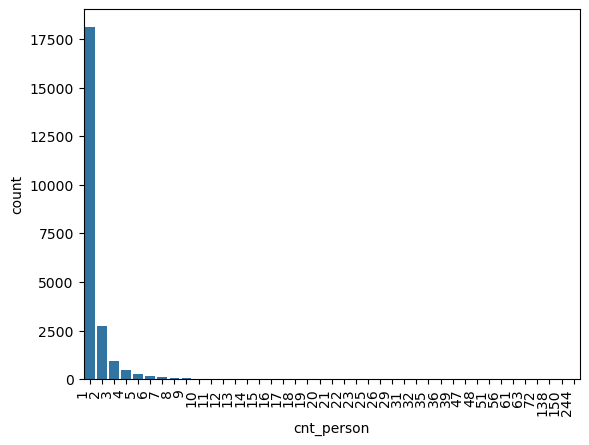

```python
sns.countplot(data=company_employee_cnt, x='cnt_person')
plt.xticks(rotation=90, ha='right')

plt.show()
```

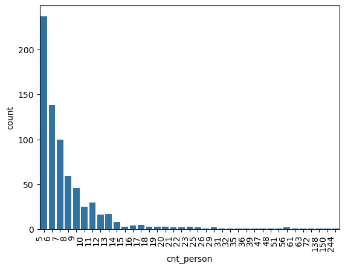

```python
sns.countplot(data=company_employee_cnt[(company_employee_cnt['cnt_person'] > 4)], x='cnt_person')
plt.xticks(rotation=90, ha='right')

plt.show()
```

В текущем распределении будет некорректно воспользоваться общепринятой классификацией организаций по кол-во персонала, т.к. в выборку попали организации с малым кол-ом сотрудников. Для сравнения создадим две группы распределения: по закону (`size_business`) и произвольное по выборке (`employee_group`), на основе статистического распределения.

```python
# Категоризируем данные с помощью метода pd.cut

company_employee_cnt['employee_group'] = pd.cut(company_employee_cnt['cnt_person'],
                                                bins=[0, 1, 4, 8, 14, float('inf')],
                                                labels=['Монокомпании', 'Малые компании',
                                                        'Средние компании', 'Крупные компании', 'Корпорации'])
company_employee_cnt['size_business'] = pd.cut(company_employee_cnt['cnt_person'],
                                                bins=[0, 15, 100, 250, float('inf')],
                                                labels=['Микропредприятие', 'Малое предприятие',
                                                        'Среднее предприятие', 'Крупное предприятие'])
company_employee_cnt
```

| company_id | cnt_person | sum_edu | mean_edu | perc_no_edu | employee_group | size_business |
| --- | --- | --- | --- | --- | --- | --- |
| 1.00 | 2 | 1 | 0.50 | 0.50 | Малые компании | Микропредприятие |
| 2.00 | 1 | 1 | 1.00 | 0.00 | Монокомпании | Микропредприятие |
| 3.00 | 3 | 3 | 1.00 | 0.00 | Малые компании | Микропредприятие |
| 4.00 | 13 | 13 | 1.00 | 0.00 | Крупные компании | Микропредприятие |
| 5.00 | 61 | 53 | 0.87 | 0.13 | Корпорации | Малое предприятие |
| ... | ... | ... | ... | ... | ... | ... |
| 285897.00 | 2 | 2 | 1.00 | 0.00 | Малые компании | Микропредприятие |
| 285953.00 | 1 | 0 | 0.00 | 1.00 | Монокомпании | Микропредприятие |
| 285972.00 | 2 | 1 | 0.50 | 0.50 | Малые компании | Микропредприятие |
| 285996.00 | 1 | 1 | 1.00 | 0.00 | Монокомпании | Микропредприятие |
| 286091.00 | 6 | 5 | 0.83 | 0.17 | Средние компании | Микропредприятие |

22921 rows × 6 columns

```python
# группируем по категориям, основанным на статистическом анализе

group_category = company_employee_cnt.groupby('employee_group', observed=False).agg({'perc_no_edu': 'mean'})
group_category
```

| employee_group | perc_no_edu |
| --- | --- |
| Монокомпании | 0.37 |
| Малые компании | 0.31 |
| Средние компании | 0.24 |
| Крупные компании | 0.21 |
| Корпорации | 0.22 |

```python
# группируем по категориям, основанным на законодательстве

group_category_size = company_employee_cnt.groupby('size_business', observed=False).agg({'perc_no_edu': 'mean'})
group_category_size
```

| size_business | perc_no_edu |
| --- | --- |
| Микропредприятие | 0.35 |
| Малое предприятие | 0.23 |
| Среднее предприятие | 0.17 |
| Крупное предприятие | NaN |

#### Вывод:

> - Оценим, насколько информация об образовании сотрудников полна. Используя датасеты `people.csv` и `education.csv`, разделим все компании на несколько групп по количеству сотрудников и оценим среднюю долю сотрудников без информации об образовании в каждой из групп. Обоснуйте выбранные границы групп.

При категоризации компании по численности персонала выявлены следующие категории по доли отсутствия информации об образовании:

- Монокомпании (до 1 сотрудника) - 37%;
- Малые компании (от 2 до 4) - 31%;
- Средние компании (от 5 до 8) - 24%;
- Крупные компании (от 9 до 14) - 21%;
- Корпорации (от 15 и более) - 22%;

Выбор границ был сделан на основе распределения данных по квартилям и процентилям. Оказалось, что 99% организаций располагает 8 и менее сотрудниками. Оставшийся 1% от 9 и до 244 сотрудников. При этом лишь на 3 компании более 100 человек. Разделение на равные группы или по законодательству (пример в анализе) могут исказить выводы или показать не полную картину.

Распределение достаточно очевидное, так как более крупные компании располагают бОльшими деньгами для привлечения более ценных кадров.

> - Оценим, возможно ли для выполнения задания присоединить к этим таблицам ещё и таблицу `degrees.csv`.

Возможно. Присоединение оказало положительный результат, так как с помощью столбца `subject` удалось получить дополнительные данные об образовании и специальности.

### 2.3. Объединять или не объединять — вот в чём вопрос

Некоторые названия столбцов встречаются в датасетах чаще других. В результате предварительной проверки датасетов было выяснено, что столбец `company_id` подходит для объединения данных.

- Установим, подходит ли для объединения данных столбец `network_username`, который встречается в нескольких датасетах. Нам необходимо понимать, дублируется ли для разных датасетов информация в столбцах с таким названием, и если да — то насколько часто.
- Оценим, можно ли использовать столбцы с именем `network_username` для объединения данных.

> Воспользуемся множествами python. Из каждого столбца `network_username` каждого датафрейма создадим множество через `set`

> После этого с помощью метода `intersection` найдем совпадения в сериях

> Если число (доля) совпадений большое, в таком случае стоит рассмотреть возможность объединить датафреймы

```python
# Создадим множество для датафрейма и посчитаем кол-во уникальных значений с помощью set
# Перед этим удалим пропуски, чтобы избежать искажения

company_and_rounds_df_notna = company_and_rounds_df.dropna(subset=['network_username'])

set_company_and_rounds = set(company_and_rounds_df_notna['network_username'])
len(set_company_and_rounds)
```

```
79571
```

```python
people_df_notna = people_df.dropna(subset=['network_username'])

set_people = set(people_df_notna['network_username'])
len(set_people)
```

```
38421
```

```python
fund_df_notna = fund_df.dropna(subset=['network_username'])

set_fund = set(fund_df_notna['network_username'])
len(set_fund)
```

```
2098
```

Столбец `network_username` содержит уникальных значений:

- в `company_and_rounds_df` - 79571
- в `people_df` - 38421
- в `fund_df` - 2098

Теперь посмотрим на кол-во совпадений в этих столбцах между датафреймами

```python
print(f'Кол-во совпадений между company_and_rounds_df и people_df: {len(set_company_and_rounds.intersection(set_people))}')
print(f'% совпадений для company_and_rounds_df: {round(len(set_company_and_rounds.intersection(set_people)) / len(set_company_and_rounds)  * 100, 2)} %')
print(f'% совпадений для people_df: {round(len(set_company_and_rounds.intersection(set_people)) / len(set_people) * 100, 2)} %')
```

```
Кол-во совпадений между company_and_rounds_df и people_df: 2199
% совпадений для company_and_rounds_df: 2.76 %
% совпадений для people_df: 5.72 %
```

```python
print(f'Кол-во совпадений между company_and_rounds_df и fund_df: {len(set_company_and_rounds.intersection(set_fund))}')
print(f'% совпадений для company_and_rounds_df: {round(len(set_company_and_rounds.intersection(set_fund)) / len(set_company_and_rounds) * 100, 2)} %')
print(f'% совпадений для fund_df: {round(len(set_company_and_rounds.intersection(set_fund)) / len(set_fund) * 100, 2)} %')
```

```
Кол-во совпадений между company_and_rounds_df и fund_df: 70
% совпадений для company_and_rounds_df: 0.09 %
% совпадений для fund_df: 3.34 %
```

```python
print(f'Кол-во совпадений между people_df и fund_df: {len(set_people.intersection(set_fund))}')
print(f'% совпадений для people_df: {round(len(set_people.intersection(set_fund)) / len(set_people) * 100, 2)} %')
print(f'% совпадений для fund_df: {round(len(set_people.intersection(set_fund)) / len(set_fund) * 100, 2)} %')
```

```
Кол-во совпадений между people_df и fund_df: 79
% совпадений для people_df: 0.21 %
% совпадений для fund_df: 3.77 %
```

#### Вывод:

> - Установим, подходит ли для объединения данных столбец `network_username`, который встречается в нескольких датасетах. Нам необходимо понимать, дублируется ли для разных датасетов информация в столбцах с таким названием, и если да — то насколько часто.

Согласно описанию столбцов датафреймов, столбец `network_username` имеет разное назначение:

- В `company_and_rounds_df` он относится к сетям компании;
- В `people_df` - к сетям сотрудников;
- В `fund_df` - к сетям компании или фонда;

Одна из гипотез для проведения числового анализа - много компаний с одним сотрудником. Возможно, что ник в сети одинаковый для таких компаний.

Во время анализа выявлено, что % совпадений между датафреймами составляет не более 5,72%, а именно:

- Для `company_and_rounds_df` и `people_df` составляет 2.76% и 5.72% соответственно;
- Для `company_and_rounds_df` и `fund_df` составляет 0.09% и 3.34% соответственно;
- Для `people_df` и `fund_df` составляет 0.21% и 3.77% соответственно.

На основании данных, можно сделать вывод, что информация не дублируется, но имеются совпадения.

Причины совпадений могут быть разные: например, случайное совпадение или сотрудники могли указать корпоративный ник в сети (к примеру, директор, PR и т.д.)

> - Оценим, можно ли использовать столбцы с именем `network_username` для объединения данных.

Из-за очень маленькой доли совпадений объединение по столбцу `network_username` нецелесообразно.

### 2.4. Проблемный датасет и причина возникновения пропусков

Во время собственного анализа данных у заказчика больше всего вопросов возникло к датасету `company_and_rounds.csv`. В нём много пропусков как раз в информации о раундах, которая заказчику важна.

- Приведем данные в вид, который позволит в дальнейшем проводить анализ в разрезе отдельных компаний. Проанализируем значения.

По гипотезе заказчика данные по компаниям из этой таблицы раньше хранились иначе, более удобным для исследования образом.

- Максимальным образом сохраняя данные, сохранив их связность и исключив возможные возникающие при этом ошибки, подготовим данные так, чтобы удобно было отобрать компании по параметрам и рассчитать показатели из расчёта на одну компанию без промежуточных агрегаций.

> Для того, что было возможно проводить дальнейший анализ по компаниям и раундам финансирования, возможно разделить датафрейм на два отдельных: по компаниям, и по раундам.

> Таким образом, в каждом датафрейме мы сможем не удалять лишние пропуски и не заполнять индикаторами, что позволит по-максимому сохранить данные.

Сигналы о том, почему датафрейм содержит в себе два соединенных датафрейма:

- Название `company_and_rounds` сообщает о двух тематиках (как в то время, в других по одной);
- Два столбца `company_id` - говорит о том, что в обоих датафреймах был этот столбец, по которому произошло присоединение
- У присоединенного датафрейма `rounds` одинаковое кол-во пропусков, что может свидетельствовать о левом присоединении;
- У присоединенного датафрейма `rounds` есть свой Primary Key - `funding_round_id`

Согласно описанию датасета, столбцы можно распределить следующим образом:

Для датафрейма `company_df` (таблица с данными по отдельным компаниям):

- `company_id` — идентификатор компании.
- `name` — название компании.
- `category_code` — категория области деятельности компании.
- `status` — статус компании.
- `founded_at` — дата инвестирования.
- `closed_at` — дата закрытия компании.
- `domain` — официальный сайт компании.
- `network_username` — ник компании в сети.
- `country_code` — код страны компании.
- `investment_rounds` — число инвестиционных раундов.
- `funding_rounds` — число раундов финансирования.
- `funding_total` — сумма финансирования.
- `milestones` — вехи финансирования.

Для датафрейма `rounds_df` (таблица с данными по раундам финансирования):

- `funding_round_id` — идентификатор этапа финансирования.
- `id_company` — идентификатор компании.
- `funded_at` — дата финансирования.
- `funding_round type` — тип финансирования.
- `raised_amount` — сумма финансирования.
- `pre_money_valuation` — предварительная денежная оценка.
- `participants` — число участников.
- `is_first_round` — является ли раунд первым.
- `is_last_round` — является раунд последним.

```python
# Создадим новые датафреймы company_df и rounds_df, отфильтровав по нужным столбцам, и отобразим информацию

company_df = company_and_rounds_df[['company_id', 'name', 'category_code', 'status', 'founded_at',
                                    'closed_at', 'domain', 'network_username', 'country_code',
                                    'investment_rounds', 'funding_rounds', 'funding_total', 'milestones']].copy()

rounds_df = company_and_rounds_df[['funding_round_id', 'id_company', 'funded_at', 'funding_round_type','raised_amount',
                                   'pre_money_valuation', 'participants','is_first_round', 'is_last_round']].copy()

company_df.info()
company_df.head()
```

```
<class 'pandas.core.frame.DataFrame'>
RangeIndex: 217774 entries, 0 to 217773
Data columns (total 13 columns):
 #   Column             Non-Null Count   Dtype
---  ------             --------------   -----
 0   company_id         217472 non-null  float64
 1   name               217471 non-null  object
 2   category_code      143886 non-null  object
 3   status             217472 non-null  object
 4   founded_at         109956 non-null  datetime64[ns]
 5   closed_at          3449 non-null    object
 6   domain             147159 non-null  object
 7   network_username   95534 non-null   object
 8   country_code       108607 non-null  object
 9   investment_rounds  217472 non-null  float64
 10  funding_rounds     217472 non-null  float64
 11  funding_total      217472 non-null  float64
 12  milestones         217472 non-null  float64
dtypes: datetime64[ns](1), float64(5), object(7)
memory usage: 21.6+ MB
```

|  | company_id | name | category_code | status | founded_at | closed_at | domain | network_username | country_code | investment_rounds | funding_rounds | funding_total | milestones |
| --- | --- | --- | --- | --- | --- | --- | --- | --- | --- | --- | --- | --- | --- |
| 0 | 1.00 | Wetpaint | web | operating | 2005-10-17 | NaN | wetpaint-inc.com | BachelrWetpaint | USA | 0.00 | 3.00 | 39750000.00 | 5.00 |
| 1 | 1.00 | Wetpaint | web | operating | 2005-10-17 | NaN | wetpaint-inc.com | BachelrWetpaint | USA | 0.00 | 3.00 | 39750000.00 | 5.00 |
| 2 | 1.00 | Wetpaint | web | operating | 2005-10-17 | NaN | wetpaint-inc.com | BachelrWetpaint | USA | 0.00 | 3.00 | 39750000.00 | 5.00 |
| 3 | 10.00 | Flektor | games_video | acquired | NaT | NaN | flektor.com | NaN | USA | 0.00 | 0.00 | 0.00 | 0.00 |
| 4 | 100.00 | There | games_video | acquired | NaT | NaN | there.com | NaN | USA | 0.00 | 0.00 | 0.00 | 4.00 |

```python
rounds_df.info()
rounds_df.head(10)
```

```
<class 'pandas.core.frame.DataFrame'>
RangeIndex: 217774 entries, 0 to 217773
Data columns (total 9 columns):
 #   Column               Non-Null Count  Dtype
---  ------               --------------  -----
 0   funding_round_id     52928 non-null  float64
 1   id_company           52928 non-null  float64
 2   funded_at            52680 non-null  datetime64[ns]
 3   funding_round_type   52928 non-null  object
 4   raised_amount        52928 non-null  float64
 5   pre_money_valuation  52928 non-null  float64
 6   participants         52928 non-null  float64
 7   is_first_round       52928 non-null  float64
 8   is_last_round        52928 non-null  float64
dtypes: datetime64[ns](1), float64(7), object(1)
memory usage: 15.0+ MB
```

|  | funding_round_id | id_company | funded_at | funding_round_type | raised_amount | pre_money_valuation | participants | is_first_round | is_last_round |
| --- | --- | --- | --- | --- | --- | --- | --- | --- | --- |
| 0 | 888.00 | 1.00 | 2005-10-01 | series-a | 5250000.00 | 0.00 | 2.00 | 0.00 | 1.00 |
| 1 | 889.00 | 1.00 | 2007-01-01 | series-b | 9500000.00 | 0.00 | 3.00 | 0.00 | 0.00 |
| 2 | 2312.00 | 1.00 | 2008-05-19 | series-c+ | 25000000.00 | 0.00 | 4.00 | 1.00 | 0.00 |
| 3 | NaN | NaN | NaT | NaN | NaN | NaN | NaN | NaN | NaN |
| 4 | NaN | NaN | NaT | NaN | NaN | NaN | NaN | NaN | NaN |
| 5 | NaN | NaN | NaT | NaN | NaN | NaN | NaN | NaN | NaN |
| 6 | NaN | NaN | NaT | NaN | NaN | NaN | NaN | NaN | NaN |
| 7 | NaN | NaN | NaT | NaN | NaN | NaN | NaN | NaN | NaN |
| 8 | NaN | NaN | NaT | NaN | NaN | NaN | NaN | NaN | NaN |
| 9 | NaN | NaN | NaT | NaN | NaN | NaN | NaN | NaN | NaN |

Теперь предобработаем датафреймы. Сначала отобразим информацию о пропусках и предобработаем их при необходимости

Проверим датафреймы на дубликаты

```python
def missing_values_info(df):
    missing_abs = df.isna().sum().sort_values(ascending=False)  # Абсолютное количество пропусков
    missing_rel = round(df.isna().mean().sort_values(ascending=False) * 100, 2)  # Относительное количество пропусков
    return pd.concat([missing_abs, missing_rel], axis=1, keys=['Кол-во', '% пропусков'])

missing_values_info(company_df)
```

|  | Кол-во | % пропусков |
| --- | --- | --- |
| closed_at | 214325 | 98.42 |
| network_username | 122240 | 56.13 |
| country_code | 109167 | 50.13 |
| founded_at | 107818 | 49.51 |
| category_code | 73888 | 33.93 |
| domain | 70615 | 32.43 |
| name | 303 | 0.14 |
| company_id | 302 | 0.14 |
| status | 302 | 0.14 |
| investment_rounds | 302 | 0.14 |
| funding_rounds | 302 | 0.14 |
| funding_total | 302 | 0.14 |
| milestones | 302 | 0.14 |

```python
missing_values_info(rounds_df)
```

|  | Кол-во | % пропусков |
| --- | --- | --- |
| funded_at | 165094 | 75.81 |
| funding_round_id | 164846 | 75.70 |
| id_company | 164846 | 75.70 |
| funding_round_type | 164846 | 75.70 |
| raised_amount | 164846 | 75.70 |
| pre_money_valuation | 164846 | 75.70 |
| participants | 164846 | 75.70 |
| is_first_round | 164846 | 75.70 |
| is_last_round | 164846 | 75.70 |

#### Обработаем пропуски в датафрейме `company_df`.

Для начала удалим все пропуски в колонках `company_id`, `name`, `status`, `investment_rounds`, `funding_rounds`, `funding_total`, `milestones`. Удаляем, т.к. доля пропусков очень низкая - 0,14%. Это не исказит анализ, при этом основная цель - анализа отдельных компаний. Без id и названия комании не получится провести анализ.

```python
# Удаляем пропуски `company_id`, `name`, `status`, `investment_rounds`, `funding_rounds`, `funding_total`, `milestones`

company_df = company_df.dropna(subset=['company_id', 'name', 'status', 'investment_rounds', 'funding_rounds', 'funding_total', 'milestones']).copy()

missing_values_info(company_df)
```

|  | Кол-во | % пропусков |
| --- | --- | --- |
| closed_at | 214023 | 98.41 |
| network_username | 121937 | 56.07 |
| country_code | 108864 | 50.06 |
| founded_at | 107516 | 49.44 |
| category_code | 73585 | 33.84 |
| domain | 70312 | 32.33 |
| company_id | 0 | 0.00 |
| name | 0 | 0.00 |
| status | 0 | 0.00 |
| investment_rounds | 0 | 0.00 |
| funding_rounds | 0 | 0.00 |
| funding_total | 0 | 0.00 |
| milestones | 0 | 0.00 |

Пропуски в колонках `closed_at`, `network_username`, `country_code`, `founded_at`, `category_code`, `domain` не удаляем, так как удаление большого кол-во пропусков исказит выводы по анализу. Также эти колонки не потребуются для анализа, поэтому их можем оставить без изменения.

```python
# Оптимизируем типы данных
# Заменим колонки на тип int и оптимизируем разрядность с помощью метода to_numeric

for column in ['company_id', 'investment_rounds', 'funding_rounds', 'funding_total', 'milestones']:
    company_df[column] = pd.to_numeric(company_df[column], errors='raise', downcast='integer')

company_df.info()
```

```
<class 'pandas.core.frame.DataFrame'>
Index: 217471 entries, 0 to 217471
Data columns (total 13 columns):
 #   Column             Non-Null Count   Dtype
---  ------             --------------   -----
 0   company_id         217471 non-null  int32
 1   name               217471 non-null  object
 2   category_code      143886 non-null  object
 3   status             217471 non-null  object
 4   founded_at         109955 non-null  datetime64[ns]
 5   closed_at          3448 non-null    object
 6   domain             147159 non-null  object
 7   network_username   95534 non-null   object
 8   country_code       108607 non-null  object
 9   investment_rounds  217471 non-null  int16
 10  funding_rounds     217471 non-null  int8
 11  funding_total      217471 non-null  int64
 12  milestones         217471 non-null  int8
dtypes: datetime64[ns](1), int16(1), int32(1), int64(1), int8(2), object(7)
memory usage: 18.3+ MB
```

Проверим данные на дубликаты

```python
# Считаем сумму дубликатов, используя метод duplicated
# Выводим дубликаты. Используем параметр keep=False, чтобы проверить корректность работы метода duplicated

display(f'Кол-во дублей: {company_df.duplicated().sum()}')

company_df[(company_df.duplicated(keep=False) == True)]
```

```
'Кол-во дублей: 20919'
```

|  | company_id | name | category_code | status | founded_at | closed_at | domain | network_username | country_code | investment_rounds | funding_rounds | funding_total | milestones |
| --- | --- | --- | --- | --- | --- | --- | --- | --- | --- | --- | --- | --- | --- |
| 0 | 1 | Wetpaint | web | operating | 2005-10-17 | NaN | wetpaint-inc.com | BachelrWetpaint | USA | 0 | 3 | 39750000 | 5 |
| 1 | 1 | Wetpaint | web | operating | 2005-10-17 | NaN | wetpaint-inc.com | BachelrWetpaint | USA | 0 | 3 | 39750000 | 5 |
| 2 | 1 | Wetpaint | web | operating | 2005-10-17 | NaN | wetpaint-inc.com | BachelrWetpaint | USA | 0 | 3 | 39750000 | 5 |
| 21 | 10015 | Fitbit | health | operating | 2007-10-01 | NaN | fitbit.com | fitbit | USA | 0 | 5 | 68069200 | 0 |
| 22 | 10015 | Fitbit | health | operating | 2007-10-01 | NaN | fitbit.com | fitbit | USA | 0 | 5 | 68069200 | 0 |
| ... | ... | ... | ... | ... | ... | ... | ... | ... | ... | ... | ... | ... | ... |
| 217465 | 3429 | Zend Technologies | software | operating | 1999-01-01 | NaN | zend.com | networkzend | USA | 0 | 4 | 44000000 | 6 |
| 217466 | 3429 | Zend Technologies | software | operating | 1999-01-01 | NaN | zend.com | networkzend | USA | 0 | 4 | 44000000 | 6 |
| 217469 | 43233 | Photonet | photo_video | acquired | 2010-03-01 | NaN | Photonet.com | Photonet | USA | 0 | 3 | 57500000 | 3 |
| 217470 | 43233 | Photonet | photo_video | acquired | 2010-03-01 | NaN | Photonet.com | Photonet | USA | 0 | 3 | 57500000 | 3 |
| 217471 | 43233 | Photonet | photo_video | acquired | 2010-03-01 | NaN | Photonet.com | Photonet | USA | 0 | 3 | 57500000 | 3 |

32092 rows × 13 columns

```python
# Удаляем дубликаты с помощью метода drop_duplicates

company_df = company_df.drop_duplicates()

# Проверяем количество дубликатов

display(f'Кол-во дублей: {company_df.duplicated().sum()}')

company_df.info()
```

```
'Кол-во дублей: 0'
```

```
<class 'pandas.core.frame.DataFrame'>
Index: 196552 entries, 0 to 217469
Data columns (total 13 columns):
 #   Column             Non-Null Count   Dtype
---  ------             --------------   -----
 0   company_id         196552 non-null  int32
 1   name               196552 non-null  object
 2   category_code      123186 non-null  object
 3   status             196552 non-null  object
 4   founded_at         91226 non-null   datetime64[ns]
 5   closed_at          2619 non-null    object
 6   domain             126545 non-null  object
 7   network_username   80591 non-null   object
 8   country_code       87990 non-null   object
 9   investment_rounds  196552 non-null  int16
 10  funding_rounds     196552 non-null  int8
 11  funding_total      196552 non-null  int64
 12  milestones         196552 non-null  int8
dtypes: datetime64[ns](1), int16(1), int32(1), int64(1), int8(2), object(7)
memory usage: 16.5+ MB
```

#### Обработаем пропуски в `rounds_df`

```python
# Удаляем пропуски во всем датафрейме

rounds_df = rounds_df.dropna()
```

```python
# Оптимизируем тип данных
# Заменим колонки is_last_round и is_first_round на булевый тип

rounds_df[['is_last_round', 'is_first_round']] = rounds_df[['is_last_round', 'is_first_round']].astype('bool')

# Заменим колонки на тип int и оптимизируем разрядность с помощью метода to_numeric

for column in ['participants', 'id_company', 'funding_round_id', 'raised_amount', 'pre_money_valuation']:
    rounds_df[column] = pd.to_numeric(rounds_df[column], errors='raise', downcast='integer')

rounds_df.info()
```

```
<class 'pandas.core.frame.DataFrame'>
Index: 52680 entries, 0 to 217773
Data columns (total 9 columns):
 #   Column               Non-Null Count  Dtype
---  ------               --------------  -----
 0   funding_round_id     52680 non-null  int32
 1   id_company           52680 non-null  int32
 2   funded_at            52680 non-null  datetime64[ns]
 3   funding_round_type   52680 non-null  object
 4   raised_amount        52680 non-null  int64
 5   pre_money_valuation  52680 non-null  int64
 6   participants         52680 non-null  int8
 7   is_first_round       52680 non-null  bool
 8   is_last_round        52680 non-null  bool
dtypes: bool(2), datetime64[ns](1), int32(2), int64(2), int8(1), object(1)
memory usage: 2.6+ MB
```

```python
# Считаем сумму дубликатов, используя метод duplicated для обозначения строки дубликатом bool True и sum для подсчета значений True

dubp_sum = rounds_df.duplicated().sum()

display(f'Кол-во дублей: {dubp_sum}')

# Выводим дубликаты. Используем параметр keep=False, чтобы проверить корректность работы метода duplicated

rounds_dupl = rounds_df[(rounds_df.duplicated(keep=False) == True)]

rounds_dupl
```

```
'Кол-во дублей: 0'
```

|  | funding_round_id | id_company | funded_at | funding_round_type | raised_amount | pre_money_valuation | participants | is_first_round | is_last_round |
| --- | --- | --- | --- | --- | --- | --- | --- | --- | --- |

```python
# Сбрасываем индексы таблиц

company_df = company_df.reset_index(drop=True)
rounds_df = rounds_df.reset_index(drop=True)
```

#### Вывод:

> - Приведем данные в вид, который позволит в дальнейшем проводить анализ в разрезе отдельных компаний. Проанализируем значения.

В рамках обработки датафрейма сделано:

- Датафрейм `company_and_rounds_df` разделен на два самостоятельных датафрейма `company_df` и `rounds_df`
- В датафреймах обработаны пропуски и дубликаты в столбцах, необходимых для анализа
- Оптимизированы типы данных
> - Максимальным образом сохраняя данные, сохранив их связность и исключив возможные возникающие при этом ошибки, подготовим данные так, чтобы удобно было отобрать компании по параметрам и рассчитать показатели из расчёта на одну компанию без промежуточных агрегаций.

В датафрейме `company_df` удалены пропуски и дубли в столбцах, в которых содержится уникальная информация о компании, благодаря чему можно провести анализ по определенным компаниям без дополнительныъ шагов

## Шаг 3. Исследовательский анализ объединённых таблиц

### 3.1. Объединение данных

Объединим данные для ответа на вопросы заказчика, которые касаются интересующих его компаний. Заказчика прежде всего интересуют те компании, которые меняли или готовы менять владельцев. Получение инвестиций или финансирования, по мнению заказчика, означает интерес к покупке или продаже компании.

В качестве основы для объединённой таблицы возьмем данные из обработанного датасета `company_and_rounds.csv` и выберем только те компании, у которых указаны значения `funding_rounds` или `investment_rounds` больше нуля, или те, у которых в колонке `status` указано `acquired`.

Проверим полноту и корректность получившейся таблицы.

За основу возьмем датафрейм `company_df` из задания 2.4. Этот датафрейм соответствует `company_and_rounds`, только уже предобработан.

Для фильтрации используем следующую маску:

- `company_df['funding_rounds'] > 0`
- `company_df['investment_rounds'] > 0`
- `company_df['status'] == 'acquired'`

Далее для присоединения датафрейма `acquisition_df` удалим дубликаты в столбце `acquired_company_id` для корректного присоединения.

```python
# Отфильтруем датафрейм company_df по условиям из ТЗ

company_filtered_df = company_df[(company_df['funding_rounds'] > 0) | (company_df['investment_rounds'] > 0) | (company_df['status'] == 'acquired')]
company_filtered_df
```

|  | company_id | name | category_code | status | founded_at | closed_at | domain | network_username | country_code | investment_rounds | funding_rounds | funding_total | milestones |
| --- | --- | --- | --- | --- | --- | --- | --- | --- | --- | --- | --- | --- | --- |
| 0 | 1 | Wetpaint | web | operating | 2005-10-17 | NaN | wetpaint-inc.com | BachelrWetpaint | USA | 0 | 3 | 39750000 | 5 |
| 1 | 10 | Flektor | games_video | acquired | NaT | NaN | flektor.com | NaN | USA | 0 | 0 | 0 | 0 |
| 2 | 100 | There | games_video | acquired | NaT | NaN | there.com | NaN | USA | 0 | 0 | 0 | 4 |
| 13 | 1001 | FriendFeed | web | acquired | 2007-10-01 | NaN | friendfeed.com | friendfeed | USA | 0 | 1 | 5000000 | 3 |
| 18 | 10014 | Mobclix | mobile | acquired | 2008-03-01 | NaN | mobclix.com | mobclix | USA | 0 | 1 | 0 | 4 |
| ... | ... | ... | ... | ... | ... | ... | ... | ... | ... | ... | ... | ... | ... |
| 196543 | 1344 | Vobile | web | operating | 2005-01-01 | NaN | vobileinc.com | networkmobile | USA | 0 | 1 | 10000000 | 0 |
| 196544 | 142181 | Stop Being Watched | software | operating | 2010-06-10 | NaN | stopbeingwatched.com | SBWinfonetwork | USA | 0 | 1 | 500000 | 1 |
| 196548 | 3429 | Zend Technologies | software | operating | 1999-01-01 | NaN | zend.com | networkzend | USA | 0 | 4 | 44000000 | 6 |
| 196549 | 7748 | Flowgram | web | closed | 2007-06-01 | 2008-06-11 | flowgram.com | network | USA | 0 | 1 | 1300000 | 3 |
| 196551 | 43233 | Photonet | photo_video | acquired | 2010-03-01 | NaN | Photonet.com | Photonet | USA | 0 | 3 | 57500000 | 3 |

40747 rows × 13 columns

```python
# Удалим дубликаты перед присоединением

duplicated_acquisition = acquisition_df.duplicated(subset=['acquired_company_id']).sum()

print(f'Кол-во дубликатов в acquisition_df: {duplicated_acquisition}')

acquisition_df = acquisition_df.drop_duplicates(subset=['acquired_company_id'])
```

```
Кол-во дубликатов в acquisition_df: 143
```

Дубликаты появились в момент объединения. При дублирующих значениях во второй, присоединяемой, таблице создается дополнительная строчка в итоговой.

```python
company_and_acquisition_df = company_filtered_df.merge(acquisition_df, left_on='company_id', right_on='acquired_company_id', how='left')
company_and_acquisition_df.head(10)
```

|  | company_id | name | category_code | status | founded_at | closed_at | domain | network_username | country_code | investment_rounds | funding_rounds | funding_total | milestones | id | acquiring_company_id | acquired_company_id | term_code | price_amount | acquired_at |
| --- | --- | --- | --- | --- | --- | --- | --- | --- | --- | --- | --- | --- | --- | --- | --- | --- | --- | --- | --- |
| 0 | 1 | Wetpaint | web | operating | 2005-10-17 | NaN | wetpaint-inc.com | BachelrWetpaint | USA | 0 | 3 | 39750000 | 5 | NaN | NaN | NaN | NaN | NaN | NaT |
| 1 | 10 | Flektor | games_video | acquired | NaT | NaN | flektor.com | NaN | USA | 0 | 0 | 0 | 0 | 1.00 | 11.00 | 10.00 | NaN | 20000000.00 | 2007-05-30 |
| 2 | 100 | There | games_video | acquired | NaT | NaN | there.com | NaN | USA | 0 | 0 | 0 | 4 | 20.00 | 377.00 | 100.00 | cash | 0.00 | 2005-05-29 |
| 3 | 1001 | FriendFeed | web | acquired | 2007-10-01 | NaN | friendfeed.com | friendfeed | USA | 0 | 1 | 5000000 | 3 | 1901.00 | 5.00 | 1001.00 | cash_and_stock | 47500000.00 | 2009-08-10 |
| 4 | 10014 | Mobclix | mobile | acquired | 2008-03-01 | NaN | mobclix.com | mobclix | USA | 0 | 1 | 0 | 4 | 3878.00 | 23054.00 | 10014.00 | NaN | 0.00 | 2010-09-30 |
| 5 | 10015 | Fitbit | health | operating | 2007-10-01 | NaN | fitbit.com | fitbit | USA | 0 | 5 | 68069200 | 0 | NaN | NaN | NaN | NaN | NaN | NaT |
| 6 | 100155 | MTPV | cleantech | operating | 2003-01-01 | NaN | mtpv.com | NaN | USA | 0 | 3 | 10125300 | 1 | NaN | NaN | NaN | NaN | NaN | NaT |
| 7 | 10018 | Demandbase | analytics | operating | 2006-01-01 | NaN | demandbase.com | Demandbase | USA | 0 | 3 | 33000000 | 3 | NaN | NaN | NaN | NaN | NaN | NaT |
| 8 | 100189 | Locatrix Communications | mobile | operating | 2003-11-01 | NaN | locatrix.com | NaN | AUS | 0 | 1 | 250000 | 1 | NaN | NaN | NaN | NaN | NaN | NaT |
| 9 | 10020 | Threebrix E-services Pvt Ltd | NaN | operating | NaT | NaN | NaN | NaN | NaN | 1 | 0 | 0 | 0 | NaN | NaN | NaN | NaN | NaN | NaT |

```python
company_and_acquisition_df.info()
```

```
<class 'pandas.core.frame.DataFrame'>
RangeIndex: 40747 entries, 0 to 40746
Data columns (total 19 columns):
 #   Column                Non-Null Count  Dtype
---  ------                --------------  -----
 0   company_id            40747 non-null  int32
 1   name                  40747 non-null  object
 2   category_code         35315 non-null  object
 3   status                40747 non-null  object
 4   founded_at            27807 non-null  datetime64[ns]
 5   closed_at             2128 non-null   object
 6   domain                35754 non-null  object
 7   network_username      20850 non-null  object
 8   country_code          34742 non-null  object
 9   investment_rounds     40747 non-null  int16
 10  funding_rounds        40747 non-null  int8
 11  funding_total         40747 non-null  int64
 12  milestones            40747 non-null  int8
 13  id                    9247 non-null   float64
 14  acquiring_company_id  9247 non-null   float64
 15  acquired_company_id   9247 non-null   float64
 16  term_code             1795 non-null   object
 17  price_amount          9247 non-null   float64
 18  acquired_at           9219 non-null   datetime64[ns]
dtypes: datetime64[ns](2), float64(4), int16(1), int32(1), int64(1), int8(2), object(8)
memory usage: 5.0+ MB
```

#### Вывод:

- В результате фильтрации и присоединения датафреймов получилось 40747 строки;
- Данные соответствуют своему типу данных, дополнительная обработка не требуется;
- При этом 12 колонок содержат пропуски. Стоит обратить внимание при дальнейшем анализе.

### 3.2. Анализ выбросов

Заказчика интересует обычный для рассматриваемого периода размер средств, который предоставлялся компаниям.

- По предобработанному столбцу `funding_total` графическим способом оценим, какой размер общего финансирования для одной компании будет типичным, а какой — выбивающимся.
- Опишем показатели, возвращаемые методом `.describe()`. Применимы ли к таким данным обычные способы нахождения типичных значений?

> В рамках задачи необходимо исследовать значения в столбце `funding_total`. Так как значения в этом столбце могут встречаться достаточно большие, то продублируем столбец (с название `funding_total_mln`) с изменением разрядности до миллионов. Это поможет сделать более наглядную визуализацию.

> При этом, для анализа в числовом варианте (через `describe()`) будем использовать первоначальный столбце `funding_total`, чтобы не округлять данные для выводов.

```python
# Для более наглядного отображения на графике, изменим разрядность на миллионы

company_and_acquisition_df['funding_total_mln'] = company_and_acquisition_df['funding_total'] / 1_000_000
```

```python
# Считаем данные мер разброса
# Найдем 1 и 3 квартили и IQR, а также нижнюю и верхнюю границы выбросов

q1_mln = company_and_acquisition_df['funding_total_mln'].quantile(0.25)
q3_mln = company_and_acquisition_df['funding_total_mln'].quantile(0.75)
iqr_mln = q3_mln - q1_mln
lower_bound_mln = q1_mln - 1.5 * iqr_mln
# размер финансирования не может быть отрицательным, поэтому такие значения заменим на 0 - минимально возможное
lower_bound_mln = max(0, lower_bound_mln)
upper_bound_mln = q3_mln + 1.5 * iqr_mln

print(f'Нижня граница выбросов {lower_bound_mln}')
print(f'Верхняя граница выбросов {upper_bound_mln}')
```

```
Нижня граница выбросов 0
Верхняя граница выбросов 14.126625000000002
```

```python
# Произведем похожие расчеты на чистых данных

q1 = company_and_acquisition_df['funding_total'].quantile(0.25)
q3 = company_and_acquisition_df['funding_total'].quantile(0.75)
iqr = q3 - q1
lower_bound = q1 - 1.5 * iqr
# размер финансирования не может быть отрицательным, поэтому такие значения заменим на 0 - минимально возможное
lower_bound = max(0, lower_bound)
upper_bound = q3 + 1.5 * iqr

print(f'Нижня граница выбросов {lower_bound}')
print(f'Верхняя граница выбросов {upper_bound}')
```

```
Нижня граница выбросов 0
Верхняя граница выбросов 14126625.0
```

```python
company_and_acquisition_df['funding_total'].describe()
```

```
count        40747.00
mean      10135609.64
std       56464359.98
min              0.00
25%              0.00
50%         600000.00
75%        5650650.00
max     5700000000.00
Name: funding_total, dtype: float64
```

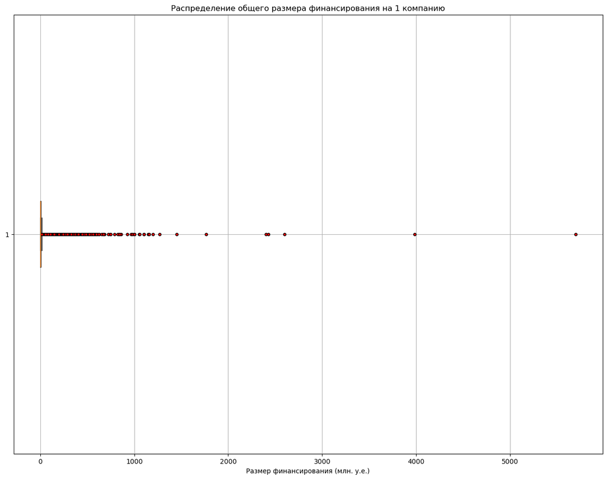

```python
# Строим диаграмму размаха

plt.figure(figsize=(16, 12))
plt.boxplot(company_and_acquisition_df['funding_total_mln'],
            flierprops=dict(markerfacecolor='r', marker='o', markersize=4),
            vert=False)
plt.title('Распределение общего размера финансирования на 1 компанию')
plt.suptitle('')
plt.xlabel('Размер финансирования (млн. у.е.)')
plt.grid(True)
plt.show()
```

В результате получился нечитаемый график из-за больших выбросов. Чтобы проанализировать типичный размер финансирования и стандартное отклонение, отфильтруем данные по нижним и верхним границам выбросов.

Проделаем фильтрацию для обоих столбцов.

```python
# Фильтруем данные, чтобы убрать выбросы на графике

filtered_outliers_mln = company_and_acquisition_df[(company_and_acquisition_df['funding_total_mln'] >= lower_bound_mln)
                                               & (company_and_acquisition_df['funding_total_mln'] <= upper_bound_mln)]

# Фильтруем данные, чтобы убрать выбросы на графике

filtered_outliers = company_and_acquisition_df[(company_and_acquisition_df['funding_total'] >= lower_bound)
                                               & (company_and_acquisition_df['funding_total'] <= upper_bound)]
```

```python
# Считаем медиану и среднее
median = filtered_outliers_mln['funding_total_mln'].median()
mean = filtered_outliers_mln['funding_total_mln'].mean()
```

```python
filtered_outliers['funding_total'].describe()
```

```
count      34889.00
mean     1870920.04
std      3145977.95
min            0.00
25%            0.00
50%       250000.00
75%      2242200.00
max     14121000.00
Name: funding_total, dtype: float64
```

```python
# Произведем похожие расчеты без выбросов

q1_flt = filtered_outliers['funding_total'].quantile(0.25)
q3_flt = filtered_outliers['funding_total'].quantile(0.75)
iqr_flt = q3_flt - q1_flt
lower_bound_flt = q1_flt - 1.5 * iqr_flt
# размер финансирования не может быть отрицательным, поэтому такие значения заменим на 0 - минимально возможное
lower_bound_flt = max(0, lower_bound_flt)
upper_bound_flt = q3_flt + 1.5 * iqr_flt

print(f'Нижня граница выбросов {lower_bound_flt}')
print(f'Верхняя граница выбросов {upper_bound_flt}')
```

```
Нижня граница выбросов 0
Верхняя граница выбросов 5605500.0
```

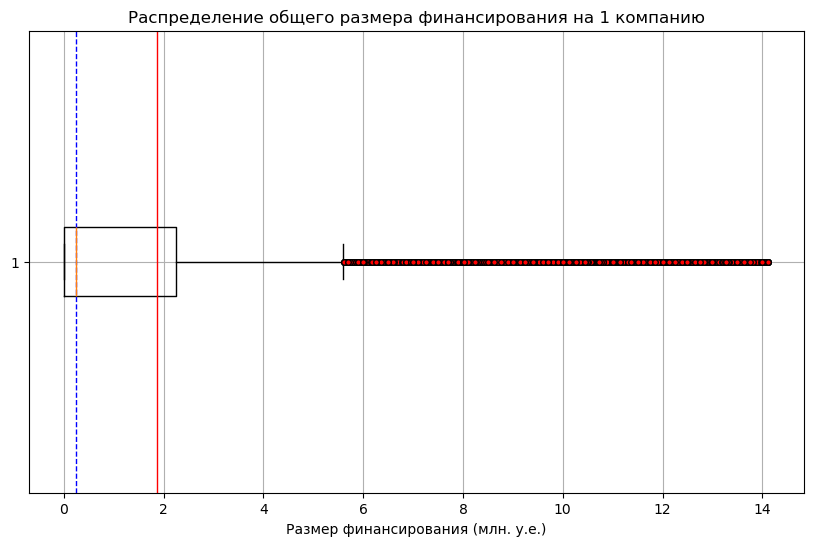

```python
# Строим диаграмму размаха

plt.figure(figsize=(10, 6))
plt.boxplot(filtered_outliers_mln['funding_total_mln'],
                          flierprops=dict(markerfacecolor='r', marker='o', markersize=4),
                          vert=False)

plt.axvline(median, color='blue', linestyle='--', linewidth=1, label=f'Медиана: {median:.1f}')
plt.axvline(mean, color='red', linestyle='-', linewidth=1, label=f'Среднее: {mean:.1f}')

plt.title('Распределение общего размера финансирования на 1 компанию')
plt.suptitle('')
plt.xlabel('Размер финансирования (млн. у.е.)')
plt.grid(True)
plt.show()
```

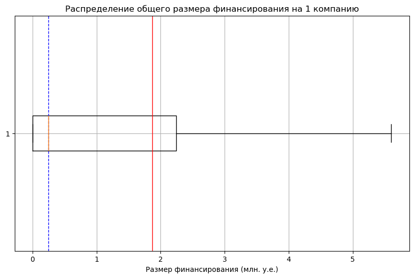

```python
# Строим диаграмму размаха без выбросов

plt.figure(figsize=(10, 6))
plt.boxplot(filtered_outliers_mln['funding_total_mln'],
                          flierprops=dict(markerfacecolor='r', marker='o', markersize=4),
                          vert=False, showfliers=False)

plt.axvline(median, color='blue', linestyle='--', linewidth=1, label=f'Медиана: {median:.1f}')
plt.axvline(mean, color='red', linestyle='-', linewidth=1, label=f'Среднее: {mean:.1f}')

plt.title('Распределение общего размера финансирования на 1 компанию')
plt.suptitle('')
plt.xlabel('Размер финансирования (млн. у.е.)')
plt.grid(True)
plt.show()
```

[figure not shown]

```python
# Дополнительно посмотрим на распределение на гистограмме

sns.histplot(data=filtered_outliers_mln, x='funding_total_mln', kde=True, bins=7)

# Добавляем линий медианы и среднего
plt.axvline(median, color='blue', linestyle='--', linewidth=1, label=f'Медиана: {median:.1f}')
plt.axvline(mean, color='red', linestyle='-', linewidth=1, label=f'Среднее: {mean:.1f}')

plt.title('Распределение баланса в зависимости от города')
plt.ylabel('Количество')
plt.show()
```

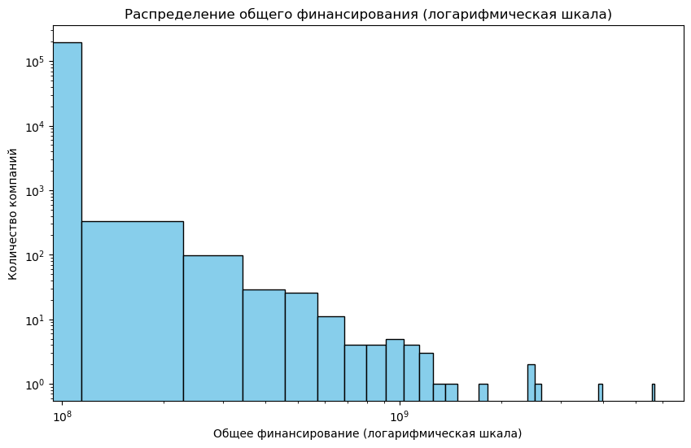

```python
# Дополнительно посмотрим на распределение на гистограмме

plt.figure(figsize=(10, 6))
plt.hist(company_df['funding_total'], bins=50, color='skyblue', edgecolor='black', log=True)
plt.xscale('log')  # Логарифмическая шкала по оси X
plt.xlabel('Общее финансирование (логарифмическая шкала)')
plt.ylabel('Количество компаний')
plt.title('Распределение общего финансирования (логарифмическая шкала)')
plt.show()
```

#### Вывод:

> - По предобработанному столбцу `funding_total` графическим способом оценим, какой размер общего финансирования для одной компании будет типичным, а какой — выбивающимся.
> - Опишем показатели, возвращаемые методом `.describe()`. Применимы ли к таким данным обычные способы нахождения типичных значений?

При анализе и построение графика можно заметить, что информация об общем финансировании для одной компании имеет выбросы в большую. На это указывают следующие признаки:

- Отличие медианы (250.000 у.е.) от среднего значения (1.870.920 у.е.);
- Правосторонняя распределение на гистограмме;
- Асимметрия "усов" на графике распределения;

Поэтому при текущих данных сложно выбрать типичный размер, так как среднее значение завышенное из-за большого кол-во выбросов и их размеров, а медиана наоборот, не учитывает крупные инвестиции. При этом, при интерпретации данных можно опираться на меры разброса:

- После удаления аномальных значений данные, можно заметить, что основная часть - межквартильный размах (IQR) - финансирования находится в диапазоне от 0 до 2.242.200 у.е.;
- Наблюдаемый минимум без учета аномалий - 0 у.е. (отрицательная сумма финансирования быть не может), максимум - 5.605.500 у.е. Это может говорить о том, есть организации, которые были приобретены за бесценок, а также компании, кто смог привлечь большое кол-во средств;
- Значения стандартного отклонения могут свидетельствовать о следующем:
  - При 0 или крайне малых суммах, может происходить формальное оформление инвестиций с целью передачи доли (например, родственникам), избежание налоговых обременений, распределение долей между основателями, финансирование материальное неденежное (например, дали офис, но оформили как финансирование) и т.д.;
  - При больших значениях - дороговизна и уникальность доработки, крупные масштабы компании, финансирование холдинга и т.д.

### 3.3. Куплены забесплатно?

- Исследуем компании, которые были проданы за ноль или за один доллар, и при этом известно, что у них был ненулевой общий объём финансирования.
- Рассчитаем аналитически верхнюю и нижнюю границу выбросов для столбца `funding_total` и укажем, каким процентилям границы соответствуют.

```python
# Отфильтруем данные по сумме покупке ['price_amount'] <= 1
# А также по сумме финансирования ['funding_total'] != 0

cheap_company = company_and_acquisition_df[(company_and_acquisition_df['price_amount'] <= 1) &
                                           (company_and_acquisition_df['funding_total'] != 0)]
cheap_company
```

|  | company_id | name | category_code | status | founded_at | closed_at | domain | network_username | country_code | investment_rounds | funding_rounds | funding_total | milestones | id | acquiring_company_id | acquired_company_id | term_code | price_amount | acquired_at | funding_total_mln |
| --- | --- | --- | --- | --- | --- | --- | --- | --- | --- | --- | --- | --- | --- | --- | --- | --- | --- | --- | --- | --- |
| 25 | 10054 | Jumptap | mobile | acquired | 2005-01-01 | NaN | jumptap.com | jumptap | USA | 0 | 7 | 121500000 | 3 | 9288.00 | 23283.00 | 10054.00 | cash_and_stock | 0.00 | 2013-08-13 | 121.50 |
| 63 | 101312 | SideTour | web | acquired | 2011-06-01 | NaN | sidetour.com | sidetour | USA | 0 | 3 | 4000000 | 2 | 9653.00 | 11391.00 | 101312.00 | NaN | 0.00 | 2013-09-18 | 4.00 |
| 66 | 101340 | ChoicePass | enterprise | acquired | 2011-07-01 | NaN | choicepass.com | choicepass | USA | 0 | 1 | 250000 | 1 | 7272.00 | 1972.00 | 101340.00 | NaN | 0.00 | 2012-06-18 | 0.25 |
| 67 | 10137 | Producteev | software | acquired | 2008-07-08 | NaN | producteev.com | producteev | USA | 0 | 3 | 1310000 | 2 | 8254.00 | 757.00 | 10137.00 | cash_and_stock | 0.00 | 2012-11-05 | 1.31 |
| 68 | 10139 | TradeCard | enterprise | acquired | 1999-01-01 | NaN | tradecard.com | TradeCard | USA | 0 | 2 | 44925000 | 1 | 9326.00 | 44008.00 | 10139.00 | NaN | 0.00 | 2013-04-01 | 44.92 |
| ... | ... | ... | ... | ... | ... | ... | ... | ... | ... | ... | ... | ... | ... | ... | ... | ... | ... | ... | ... | ... |
| 40680 | 9871 | iList | ecommerce | acquired | NaT | NaN | ilist.com | NaN | NaN | 0 | 1 | 1500000 | 2 | 7489.00 | 396.00 | 9871.00 | NaN | 0.00 | 2010-04-21 | 1.50 |
| 40692 | 99 | Amie Street | web | acquired | 2011-07-04 | NaN | amiestreet.com | amiestreet_logs | USA | 0 | 2 | 3900000 | 0 | 7024.00 | 317.00 | 99.00 | NaN | 0.00 | 2010-09-22 | 3.90 |
| 40694 | 9905 | UBmatrix | software | acquired | 2005-01-01 | NaN | ubmatrix.com | NaN | USA | 0 | 2 | 5172350 | 0 | 3381.00 | 41119.00 | 9905.00 | NaN | 0.00 | 2010-06-24 | 5.17 |
| 40698 | 992 | wunderloop | advertising | acquired | 1999-01-01 | NaN | wunderloop.com | NaN | USA | 0 | 1 | 10000000 | 1 | 9916.00 | 19182.00 | 992.00 | NaN | 0.00 | 2010-07-02 | 10.00 |
| 40729 | 153326 | Yoke | web | acquired | NaT | NaN | apps.socialnet.com::yokeapp | NaN | NaN | 0 | 1 | 500000 | 1 | 7948.00 | 2352.00 | 153326.00 | NaN | 0.00 | 2012-09-11 | 0.50 |

1584 rows × 20 columns

```python
# Посчитаем долю таких компаний от всех

round(cheap_company.shape[0] / company_df.shape[0] * 100, 2)
```

```
0.81
```

```python
group_cheap_company = cheap_company.groupby('category_code').agg({'company_id': 'count', 'funding_total': 'mean'})
group_cheap_company['perc_company'] = round(group_cheap_company['company_id'] / group_cheap_company['company_id'].sum() * 100, 1)
group_cheap_company.sort_values(by='company_id' ,ascending=False)
```

| category_code | company_id | funding_total | perc_company |
| --- | --- | --- | --- |
| software | 360 | 11457863.61 | 23.70 |
| web | 207 | 9316702.43 | 13.60 |
| enterprise | 127 | 11023299.65 | 8.40 |
| mobile | 114 | 67550469.15 | 7.50 |
| games_video | 75 | 14674291.60 | 4.90 |
| advertising | 74 | 12519489.84 | 4.90 |
| biotech | 68 | 28351425.96 | 4.50 |
| ecommerce | 56 | 15191089.48 | 3.70 |
| network_hosting | 54 | 18094710.22 | 3.60 |
| semiconductor | 43 | 23830423.26 | 2.80 |
| cleantech | 40 | 45176283.25 | 2.60 |
| hardware | 34 | 13867356.47 | 2.20 |
| analytics | 32 | 8871129.03 | 2.10 |
| security | 30 | 13534820.00 | 2.00 |
| public_relations | 26 | 19042156.58 | 1.70 |
| other | 19 | 11573411.00 | 1.30 |
| search | 18 | 21938500.00 | 1.20 |
| social | 17 | 7735882.35 | 1.10 |
| messaging | 16 | 6757562.50 | 1.10 |
| travel | 16 | 4406562.50 | 1.10 |
| health | 13 | 39215288.46 | 0.90 |
| medical | 11 | 24675721.82 | 0.70 |
| consulting | 10 | 10966652.00 | 0.70 |
| education | 10 | 4940504.00 | 0.70 |
| news | 9 | 9418652.22 | 0.60 |
| music | 8 | 9710595.00 | 0.50 |
| finance | 7 | 10165065.71 | 0.50 |
| fashion | 5 | 22410000.00 | 0.30 |
| photo_video | 3 | 2366666.67 | 0.20 |
| manufacturing | 3 | 5616666.67 | 0.20 |
| hospitality | 3 | 2451043.33 | 0.20 |
| design | 3 | 1032925.00 | 0.20 |
| legal | 2 | 12300000.00 | 0.10 |
| automotive | 2 | 8500000.00 | 0.10 |
| sports | 2 | 1600000.00 | 0.10 |
| transportation | 2 | 37852200.00 | 0.10 |

```
interval columns not set, guessing: ['company_id', 'funding_total']
```

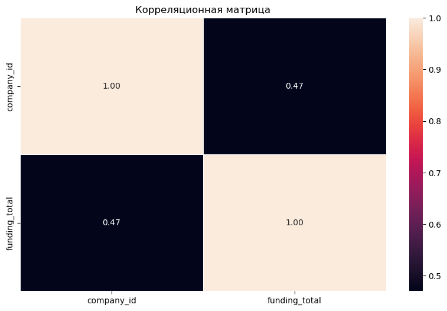

|  | company_id | funding_total |
| --- | --- | --- |
| company_id | 1.00 | 0.47 |
| funding_total | 0.47 | 1.00 |

```python
matrix_group_cheap_company = group_cheap_company[['company_id', 'funding_total']].phik_matrix()

# Строим корреляционную матрицу
plt.figure(figsize=(10, 6))
sns.heatmap(matrix_group_cheap_company,
            annot=True,
            fmt='.2f',
            linewidths=0.5)
plt.title('Корреляционная матрица')
plt.show()

matrix_group_cheap_company
```

Рассмотри меры разброса компаний, купленных за менее чем 1 доллар.

```python
# Считаем данные мер разброса
# Найдем 1 и 3 квартили и IQR, а также нижнюю и верхнюю границы выбросов

q1_cc = cheap_company['funding_total'].quantile(0.25)
q3_cc = cheap_company['funding_total'].quantile(0.75)
iqr_cc = q3_cc - q1_cc
lower_bound_cc = q1_cc - 1.5 * iqr_cc
# размер финансирования не может быть отрицательным, поэтому такие значения заменим на 0 - минимально возможное
lower_bound_cc = max(0, lower_bound_cc)
upper_bound_cc = q3_cc + 1.5 * iqr_cc

print(f'Q1: {q1_cc} \nQ3: {q3_cc}, \nIQR: {iqr_cc}')
print(f'Нижня граница выбросов {lower_bound_cc} \nВерхняя граница выбросов {upper_bound_cc}')
```

```
Q1: 2000000.0
Q3: 15400000.0,
IQR: 13400000.0
Нижня граница выбросов 0
Верхняя граница выбросов 35500000.0
```

```python
cheap_company['funding_total'].describe()
```

```
count         1584.00
mean      17859642.59
std      145666041.64
min           3750.00
25%        2000000.00
50%        6000000.00
75%       15400000.00
max     5700000000.00
Name: funding_total, dtype: float64
```

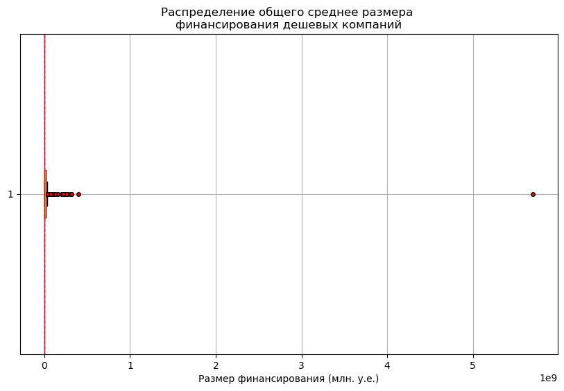

```python
# Строим диаграмму размаха

plt.figure(figsize=(10, 6))
plt.boxplot(cheap_company['funding_total'],
                          flierprops=dict(markerfacecolor='r', marker='o', markersize=4),
                          vert=False)

plt.axvline(median, color='blue', linestyle='--', linewidth=1, label=f'Медиана: {median:.1f}')
plt.axvline(mean, color='red', linestyle='-', linewidth=1, label=f'Среднее: {mean:.1f}')

plt.title('Распределение общего среднее размера \nфинансирования дешевых компаний')
plt.suptitle('')
plt.xlabel('Размер финансирования (млн. у.е.)')
plt.grid(True)
plt.show()
```

```python
# Уберем аномальный выброс

cheap_company = cheap_company[(cheap_company['funding_total'] < 299500000)]

# Приведем разрядность в читаемый вид

cheap_company['funding_total_mln'] = cheap_company['funding_total'] / 1_000_000
```

```python
cheap_company['funding_total'].describe()
```

```
count        1579.00
mean     13465619.92
std      23506363.14
min          3750.00
25%       2000000.00
50%       6000000.00
75%      15255550.00
max     265744000.00
Name: funding_total, dtype: float64
```

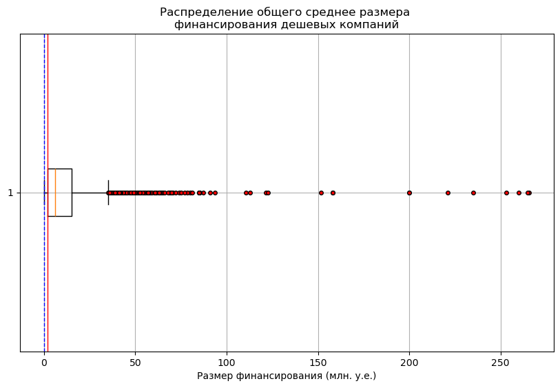

```python
# Строим диаграмму размаха

plt.figure(figsize=(10, 6))
plt.boxplot(cheap_company['funding_total_mln'],
                          flierprops=dict(markerfacecolor='r', marker='o', markersize=4),
                          vert=False)

plt.axvline(median, color='blue', linestyle='--', linewidth=1, label=f'Медиана: {median:.1f}')
plt.axvline(mean, color='red', linestyle='-', linewidth=1, label=f'Среднее: {mean:.1f}')

plt.title('Распределение общего среднее размера \nфинансирования дешевых компаний')
plt.suptitle('')
plt.xlabel('Размер финансирования (млн. у.е.)')
plt.grid(True)
plt.show()
```

```python
# Найдем процентиль, которым соответствуют границы выбросов
# Для этого отфильтруем данные по верхней границы
# Нижнюю не используем, т.к. она = 0, отрицательных данных у нас нет

cheap_company_lower = cheap_company[(cheap_company['funding_total'] < upper_bound_cc)]

round(cheap_company_lower.shape[0] / cheap_company.shape[0] * 100, 1)
```

```
91.5
```

```python
# Проверим вычисления
perc_cheap_company_lower = cheap_company['funding_total'].quantile(0.915)

print(f'Процентиль {perc_cheap_company_lower}')
print(f'Верхняя граница выбросов {upper_bound_cc}')
```

```
Процентиль 35715500.000000075
Верхняя граница выбросов 35500000.0
```

#### Вывод:

> - Исследуем компании, которые были проданы за ноль или за один доллар, и при этом известно, что у них был ненулевой общий объём финансирования.

Возможные причины, почему компании могли быть куплены за менее чем 1 доллар:

- Финансовые трудности компании. Компании могли испытывать сложности с финансированием, а бизнес-ангелы (венчурные инвесторы) помогли оставить компанию на плаву, взамен получив долю в компании. Этим ка раз может объясняться большой размер финансирования. Для подтверждения гипотез было бы неплохо посмотреть фин.отчетность;
- Символическая сделка для передачи прав или доли. С одной стороны, это не соотносится с большим размером финансирования, с другой стороны - компания могла быть только частью крупной сделки.
- Поглощение ради активов. Этой гипотезой объясняется то, что компании принадлежат к IT сектору - покупка компании ради особенной технологии и команды;
- Также есть другие причины, например, списание долгов, отсутствие ценности компании и т.п., но это не соотносится с тем, что выли выделены средства на финансирование.

### 3.4. Цены стартапов по категориям

Категории стартапов с типично высокими ценами покупки стартапов и значительным разбросом цен могут быть привлекательными для крупных инвесторов, которые готовы к высоким рискам ради потенциально больших доходов. Среди категорий стартапов выделим категории стартапов, характеризующиеся:

- типично высокими ценами;
- и наибольшим разбросом цен за стартап.

Почему решили составить топ именно из такого числа категорий и почему рассчитывали именно так.

```python
# отфильтруем данные без нулевой цены
notna_price_amount = company_and_acquisition_df[(company_and_acquisition_df['price_amount'] != 0)]

# Сгруппируем значения по категории стартапа
# Произведем агрегацию по медиане и стандартному отклонению

group_company_and_acquisition = notna_price_amount.groupby('category_code').agg(company_count=('company_id', 'count'),
                                                        price_median=('price_amount', 'median'),
                                                        price_std=('price_amount', 'std')).reset_index()
```

```python
# Отфильтруем компании, у которых нет цены и не удалось рассчитать стандартное отклонение,
# т.к. по ТЗ они не представляют для нас ценности
# дополнительно отфильтруем стандартное отклонение по 90 процентилю, т.к. выбросы сильно на него влияют

group_company_and_acquisition = group_company_and_acquisition[(group_company_and_acquisition['price_median'] != 0) &
                                                              (group_company_and_acquisition['price_median'].notna()) &
                                                              (group_company_and_acquisition['price_std'].notna()) &
                                                              (group_company_and_acquisition['price_std'] < group_company_and_acquisition['price_std'].quantile(0.90))]
group_company_and_acquisition.sort_values(by='price_median', ascending=False)
```

|  | category_code | company_count | price_median | price_std |
| --- | --- | --- | --- | --- |
| 38 | sports | 121 | 622500000.00 | 512652416.36 |
| 19 | manufacturing | 386 | 351000000.00 | 1060434506.33 |
| 39 | transportation | 95 | 230000000.00 | 572625532.09 |
| 3 | biotech | 3407 | 200000000.00 | 1971954949.74 |
| 1 | analytics | 665 | 200000000.00 | 92967736.34 |
| 10 | fashion | 243 | 195000000.00 | 86494219.46 |
| 7 | ecommerce | 1615 | 180000000.00 | 282331182.18 |
| 4 | cleantech | 1068 | 177500000.00 | 885383455.83 |
| 11 | finance | 597 | 171500000.00 | 1052920128.98 |
| 34 | security | 403 | 169000000.00 | 1395628675.19 |
| 20 | medical | 691 | 165000000.00 | 165905784.01 |
| 15 | health | 633 | 140000000.00 | 1927099525.34 |
| 25 | network_hosting | 502 | 102500000.00 | 676956798.47 |
| 35 | semiconductor | 468 | 100000000.00 | 1122024807.98 |
| 21 | messaging | 226 | 100000000.00 | 69074597.36 |
| 33 | search | 303 | 90000000.00 | 339580152.22 |
| 14 | hardware | 1113 | 76000000.00 | 645087366.05 |
| 40 | travel | 224 | 62500000.00 | 95265856.07 |
| 0 | advertising | 1211 | 58500000.00 | 491459531.41 |
| 16 | hospitality | 298 | 57500000.00 | 790600556.24 |
| 9 | enterprise | 1587 | 56500000.00 | 1614921635.16 |
| 22 | mobile | 2064 | 56000000.00 | 1319471637.21 |
| 12 | games_video | 1385 | 51500000.00 | 1487437888.75 |
| 30 | photo_video | 154 | 50000000.00 | 431142213.99 |
| 41 | web | 2866 | 50000000.00 | 644773198.54 |
| 37 | software | 4666 | 48070000.00 | 1193245392.80 |
| 36 | social | 592 | 45750000.00 | 62952859.35 |
| 26 | news | 221 | 40000000.00 | 100855335.07 |
| 5 | consulting | 400 | 32150000.00 | 1050906069.88 |
| 8 | education | 533 | 16250000.00 | 288329370.95 |
| 23 | music | 183 | 4860000.00 | 159978081.42 |

```python
# техническая строка для проверки корректности подсчета в сгруппированной таблице

notna_price_amount[(notna_price_amount['category_code'] == 'music')]['price_amount'].std()
```

```
159978081.41534057
```

Теперь из списка нам надо выбрать категории стартапов с типично высокими ценами покупки и значительным разбросом цен, т.к. они могут быть привлекательными для крупных инвесторов.

Чтобы отобрать такие компании сложно и не совсем корректно ориентироваться на один показатель. Для этого рассмотрим кол-во компаний в категории, их среднюю цену и разброс. Почему важно ориентироваться на них:

- Небольшое кол-во стартапов в категории может исказить выводы, т.к. данные будут основаны на маленьком кол-ве случаев, что может привести к ошибке выжившего;
- Только средняя цена может не показать потенциально перспективные категории, так как из-за подсчета может пропустить потенциальную выгоду;
- Разброс может быть сформирован на низких ценах с аномалиями и большими выбросами, не учитывая положение категории (отрасли) - тоже своего рода ошибка выжившего.

Поэтому для отбора компаний будем учитывать все три показателя в совокупности.

```python
# Отфильтруем категории по кол-во компаний в каждой категории,
# по средней стоимости более медианы
# по стандартному отклонению более медианы

top_category_company = group_company_and_acquisition[(group_company_and_acquisition['company_count'] > group_company_and_acquisition['company_count'].quantile(0.25)) &
                                                     (group_company_and_acquisition['price_median'] > group_company_and_acquisition['price_median'].median()) &
                                                     (group_company_and_acquisition['price_std'] > group_company_and_acquisition['price_std'].median())]
top_category_company.reset_index(drop=True)
```

|  | category_code | company_count | price_median | price_std |
| --- | --- | --- | --- | --- |
| 0 | biotech | 3407 | 200000000.00 | 1971954949.74 |
| 1 | cleantech | 1068 | 177500000.00 | 885383455.83 |
| 2 | finance | 597 | 171500000.00 | 1052920128.98 |
| 3 | health | 633 | 140000000.00 | 1927099525.34 |
| 4 | manufacturing | 386 | 351000000.00 | 1060434506.33 |
| 5 | network_hosting | 502 | 102500000.00 | 676956798.47 |
| 6 | security | 403 | 169000000.00 | 1395628675.19 |
| 7 | semiconductor | 468 | 100000000.00 | 1122024807.98 |

#### Вывод:

> Категории стартапов с типично высокими ценами покупки стартапов и значительным разбросом цен могут быть привлекательными для крупных инвесторов, которые готовы к высоким рискам ради потенциально больших доходов. Среди категорий стартапов выделим категории стартапов, характеризующиеся:
> - типично высокими ценами;
> - и наибольшим разбросом цен за стартап.

> Почему решили составить топ именно из такого числа категорий и почему рассчитывали именно так.

Для выбора перспективных категорий стартапов с высокими ценами покупки и значительным разбросом цен важно учитывать три ключевых показателя:

- **Количество компаний** – малая выборка может искажать данные (ошибка выжившего).
- **медианная цена** – один только этот показатель может не отражать полный потенциал.
- **Разброс цен** – важно исключить аномалии и случайные выбросы.

Критерии отбора: категории, где Количество компаний свыше 1 квартиля и медиана и разброс выше медианных значений. Это отсеет наименее перспективные варианты в каждом показателе и минимизирует влияние статистических ошибок.

Таким образом, отбор строится на комплексной оценке, что повышает надежность выбора для крупных инвесторов.

### 3.5. Сколько раундов продержится стартап перед покупкой

- Проанализируем столбец `funding_rounds` и исследуем его значение, т.к. заказчика интересует типичное значение количества раундов для каждого возможного статуса стартапа.
- Построим график, который отображает, сколько в среднем раундов финансирования проходило для стартапов из каждой группы.

Расшифруем обозначения статусов

- ipo - компания находится в процессе первичного размещения ценных бумаг;
- operating - компания в рабочем статусе, осуществляет свою деятельность;
- closed - компания закрыта;
- acquired - компания приобретена.

```python
# Сгруппируем значения по категории стартапа
# Произведем агрегацию по средней и стандартному отклонению
# Медиану не используем из-за

group_status_company = company_and_acquisition_df.groupby('status').agg(company_cnt=('company_id', 'count'),
                                                                        rounds_mean=('funding_rounds', 'mean'))
group_status_company = group_status_company.sort_values(by='rounds_mean', ascending=False)
group_status_company
```

| status | company_cnt | rounds_mean |
| --- | --- | --- |
| ipo | 640 | 1.93 |
| operating | 28621 | 1.52 |
| closed | 2092 | 1.38 |
| acquired | 9394 | 0.52 |

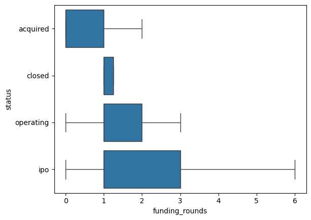

```python
median_order = company_and_acquisition_df.groupby('status')['funding_rounds'].mean().sort_values().index

sns.boxplot(data=company_and_acquisition_df,
            x='funding_rounds',
            y='status',
            order=median_order,
            showfliers=False)
```

```python
def quantile_status(status):
    q1_st = company_and_acquisition_df[(company_and_acquisition_df['status'] == status)]['funding_rounds'].quantile(0.25)
    q3_st = company_and_acquisition_df[(company_and_acquisition_df['status'] == status)]['funding_rounds'].quantile(0.75)
    iqr_st = q3_st - q1_st
    lower_bound_st = q1_st - 1.5 * iqr_st
    lower_bound_st = max(0, lower_bound_st)
    upper_bound_st = q3_st + 1.5 * iqr_st
    print(f'Статус \'{status}\':')
    print(f'Q1: {q1_st} \nQ3: {q3_st}, \nIQR: {iqr_st}')
    print(f'Нижня граница выбросов {lower_bound_st} \nВерхняя граница выбросов {upper_bound_st}\n')

for status in ['ipo', 'operating', 'closed', 'acquired']:
    quantile_status(status)
```

```
Статус 'ipo':
Q1: 1.0
Q3: 3.0,
IQR: 2.0
Нижня граница выбросов 0
Верхняя граница выбросов 6.0

Статус 'operating':
Q1: 1.0
Q3: 2.0,
IQR: 1.0
Нижня граница выбросов 0
Верхняя граница выбросов 3.5

Статус 'closed':
Q1: 1.0
Q3: 1.25,
IQR: 0.25
Нижня граница выбросов 0.625
Верхняя граница выбросов 1.625

Статус 'acquired':
Q1: 0.0
Q3: 1.0,
IQR: 1.0
Нижня граница выбросов 0
Верхняя граница выбросов 2.5
```

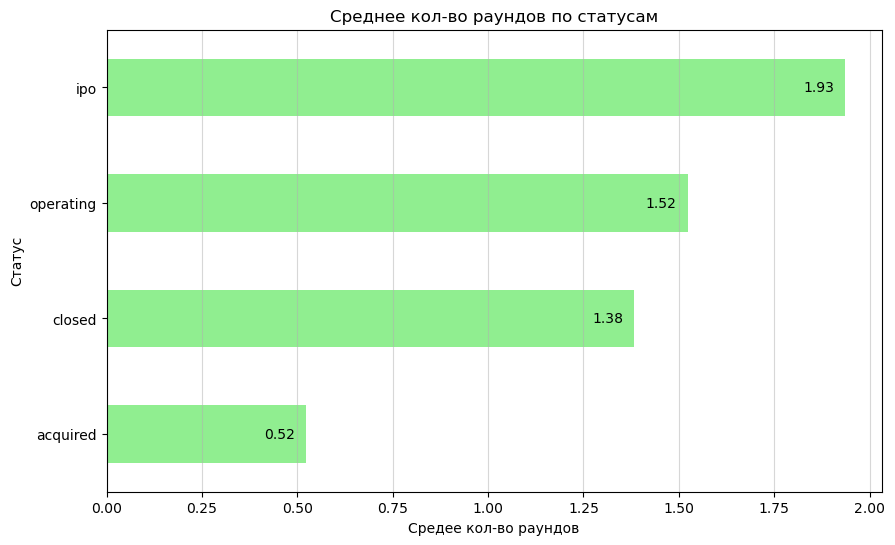

```python
for index, value in enumerate(group_status_company['rounds_mean']):
    group_status_company['rounds_mean'].plot.barh(figsize=(10, 6),
                                              color='lightgreen',
                                              title='Среднее кол-во раундов по статусам',
                                              xlabel='Средее кол-во раундов',
                                              ylabel='Статус').annotate(f'{value:.2f}', xy=(value, index), xytext=(-30, 0), textcoords='offset points', va='center')

plt.gca().invert_yaxis()
plt.grid(axis='x', linestyle='-', alpha=0.5)
```

#### Вывод:

> - Необходимо проанализировать столбец `funding_rounds`. Исследуйте значения столбца. Заказчика интересует типичное значение количества раундов для каждого возможного статуса стартапа.
- IPO:
  - Среднее кол-во раундов 1,9;
  - В рамках размаха от 1 до 3 раундов;
  - Допустимые значения (граница выбросов) от 0 до 6 раундов.
- Operating:
  - Среднее кол-во раундов 1,5;
  - В рамках размаха от 1 до 2 раундов;
  - Допустимые значения до 3,5 раундов.
- Closed:
  - Среднее кол-во раундов 1,4;
  - В рамках размаха от 1 до 1,3 раундов;
  - Допустимые значения до 1,6 раундов.
- Acquired:
  - Среднее кол-во раундов 0,5;
  - В рамках размаха от 0 до 1 раундов;
  - Допустимые значения до 2,5 раундов.
> - Постройте график, который отображает, сколько в среднем раундов финансирования проходило для стартапов из каждой группы. Сделайте выводы.
- Стартапы, которые достигают стадии IPO, обычно проходят несколько раундов финансирования, что указывает на их устойчивость и привлекательность для инвесторов. Однако значительное количество раундов (более 6) может быть связано с долгим развитием или сложностями в привлечении средств.
- Действующие компании обычно проходят меньше раундов финансирования, что может свидетельствовать о том, что они либо быстро достигают стабильности, либо не требуют значительных инвестиций для поддержания своей деятельности.
- Закрытые компании, как правило, проходят минимальное количество раундов финансирования. Это может быть связано с их неспособностью привлечь дополнительные инвестиции или с неудачами в реализации бизнес-модели.
- Компании, которые были приобретены, часто проходят минимальное количество раундов финансирования. Это может быть связано с тем, что они были приобретены на ранних стадиях развития, либо их технологии или активы были привлекательны для покупателей.

Рекомендации:

- Для оценки перспективности стартапов можно учитывать их статус и количество раундов финансирования. Например, стартапы с большим количеством раундов (более 3) могут быть более зрелыми и устойчивыми, но также могут указывать на сложности в привлечении средств.
- Компании с минимальным количеством раундов (0–1) могут быть интересны для приобретения, если они обладают уникальными активами или технологиями.

## Шаг 4. Итоговый вывод и рекомендации

Шаг 1. Знакомство с данными: загрузка и первичная предобработка

- Загрузка данных:
  - Получены датафреймы с информацией о стартапах, инвестиционных раундах, сотрудниках и фондах.
- Стиль данных:
  - Приведены к единому формату (snake_case).
- Типы данных:
  - Столбцы с датами преобразованы из object в datetime.
- Пропуски:
  - Обнаружены пропуски, требующие дальнейшего анализа.

Рекомендации: Провести углублённый анализ данных на предмет пропусков, дубликатов, обработки каждого датафрейма и столбца.

Шаг 2. Предобработка данных и предварительное исследование

- 2.1 Раунды финансирования по годам
  - Максимальный типичный размер средств, выделяемых в рамках одного раунда, был зафиксирован в 2005 году и составил 5 500 000 у.е..
  - В 2013 году наблюдалась обратная зависимость - чем больше раундов, тем меньше предлагали сумму финансирования в рамках раунда
- 2.2 Образование сотрудников Компании были разделены на группы по количеству сотрудников:
  - Монокомпании (до 1 сотрудника): 37%.
  - Малые компании (2–4 сотрудников): 31%.
  - Средние компании (5–8 сотрудников): 24%.
  - Крупные компании (от 9 до 14 сотрудников): 21%.
  - Корпорации (от 15 и более) - 22%
- 2.3. Объединение данных
  - Низкий процент совпадений по network_username (<6%). Объединение по этому полю нецелесообразно.
- 2.4. Обработка пропусков и дубликатов
  - Датафреймы разделены (company_df и rounds_df).
  - Удалены дубликаты и оптимизированы типы данных.

Рекомендации:

- Учитывать тренд 2013 года (малые, но частые раунды).
- Дополнить данные об образовании ключевых сотрудников.

Шаг 3. Исследовательский анализ объединённых таблиц

**Рекомендации:** На основе полученных результатам рекомендую присмотреться к следующим секторам стартапов для инвестирования:

- Потенциально высокодоходные категории biotech, cleantech, manufacturing, health;
- При инвестировании обращать внимание на статус стартапа: стартапы с большим количеством раундов (более 3) могут быть более зрелыми и устойчивыми, но также могут указывать на сложности в привлечении средств.
- Компании с минимальным количеством раундов (0–1) могут быть интересны для приобретения, если они обладают уникальными активами или технологиями.
- Стоит проявлять активность на рынке: могут попадаться компании с хорошим потенциалом, но в сложной ситуации. Такие стартапы можно выкупить по выгодной стоимости.